# Tugas-Pertemuan-4

**Nur Annisa Hartanti Putri - M0401241051**

# White Noise

```r
set.seed(1234)
wn <- rnorm(300)
```

# Proses MA(2)

Dalam kasus ini, akan dibangkitkan suatu data dengan model MA(2) sebanyak 300 data yang memiliki nilai θ1=0.4 dan θ2=0.6. Rumusan model tersebut adalah sebagai berikut

$$Y_t = c + e_t + \theta_1 e_{t-1} + \theta_2 e_{t-2}$$

$$Y_t = e_t + 0.4e_{t-1} + 0.6e_{t-2}$$

## Membangkitkan Model MA(2)

### Manual

```r
ma2_manual <- c(wn[1], wn[2] + 0.4 * wn[1])

for(i in 3:300){
  ma2_manual[i] <- wn[i] + 0.4 * wn[i - 1] + 0.6 * wn[i - 2]
}

ma2_manual
```

```
##   [1] -1.207065749 -0.205397058  0.471173424 -1.745463687  0.141510314
##   [6] -0.729712854 -0.114842790 -0.472894305 -1.127948717 -1.443797742
##  [11] -1.171879031 -1.723286222 -1.461924092 -0.845074607  0.519525249
##  [16]  0.312187420  0.020572732 -1.181770516 -1.508255550  1.534249256
##  [21]  0.598119283  1.012450498 -0.556369299 -0.011041246 -0.774213194
##  [26] -1.449939345 -0.420758391 -1.662676381 -0.079747157 -1.556197355
##  [31]  0.718835126 -0.596243221 -0.238298741 -1.070389923 -2.255260716
##  [36] -2.120011486 -3.624543435 -2.913580609 -2.138714925 -1.388210999
##  [41]  1.086560934 -0.768382742 -0.413123964 -1.263954490 -1.619808057
##  [46] -1.534624150 -2.091327966 -2.276021753 -1.689013389 -1.457572736
##  [51] -2.319068111 -1.602598402 -2.425338748 -1.807763414 -1.233628102
##  [56] -0.110845196  1.775654086  0.223607057  2.285258743 -0.979456751
##  [61]  1.157010823  2.116941328  1.378789117  0.845856907 -0.296314421
##  [66]  1.372262398 -0.432336811  1.978634754  1.193531021  1.688995021
##  [71]  0.939220832 -0.250827924 -0.544575725  0.228395751  2.109671129
```

[output cut: 45 more lines]

### arima.sim

```r
ma2_arima <- arima.sim(list(order=c(0,0,2), ma=c(0.4, 0.6)), n=300)
ma2_arima
```

```
## Time Series:
## Start = 1
## End = 300
## Frequency = 1
##   [1] -0.908714261  0.366069559  0.319892749 -0.033692645 -0.749809541
##   [6]  1.023224875 -0.103827746  1.553027734  1.508813504  1.490258435
##  [11]  0.638775303  0.057508568 -0.761313741  1.006804154  0.046165301
##  [16]  2.226792228 -0.031351321  0.058227766 -0.452682262 -0.306828839
##  [21] -0.408896770 -1.768664231 -0.905163217 -1.653388217  0.814020129
##  [26] -0.949587092  1.394975120 -0.770061199  0.708742509  0.626264945
##  [31]  0.016220780  0.886163244 -0.177443664 -0.837739266 -0.776948985
##  [36]  0.830630275  0.271737011  0.068438994 -0.509614613 -0.182137038
##  [41]  1.054967504  1.724174690  1.131301118  1.891160132 -0.238116411
##  [46] -1.951472236 -1.868044756 -2.111236903 -2.805388403 -0.673455997
##  [51] -1.948408128 -0.202080988 -2.147789666 -0.222949385  1.157974906
```

[output cut: 49 more lines]

## Karakteristik MA(2)

### Plot Time Series

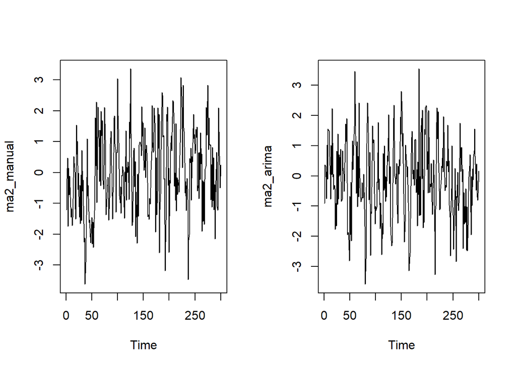

```r
par(mfrow = c(1, 2))
ts.plot(ma2_manual)
ts.plot(ma2_arima)
```

Berdasarkan plot time series, terlihat bahwa data MA(2) berfluktuasi di sekitar nilai rata-rata yang relatif konstan dan tidak menunjukkan adanya tren yang jelas sehingga data dapat dikatakan **stasioner** dalam rataan.

### Plot ACF

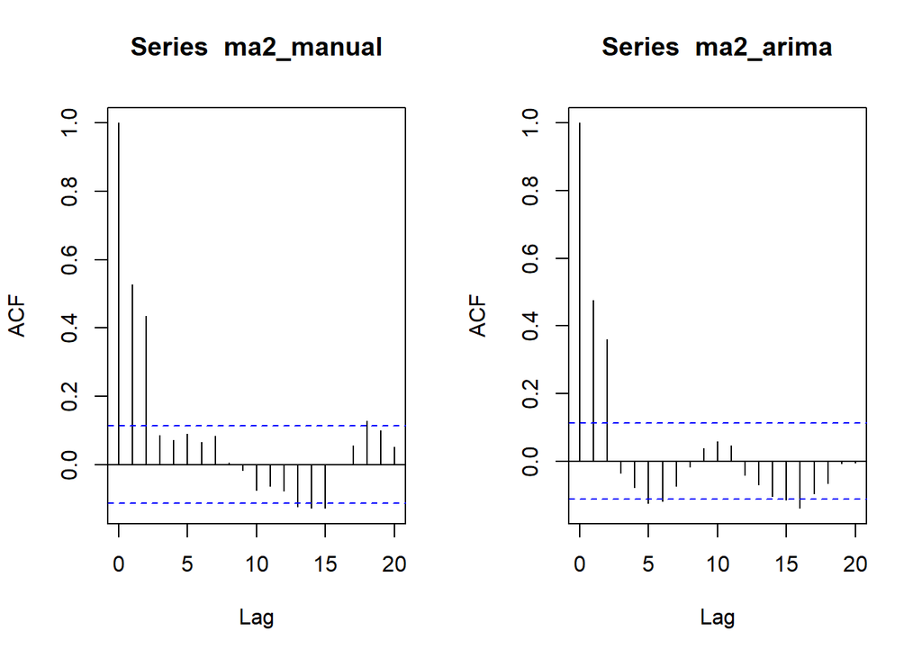

```r
par(mfrow = c(1, 2))
acf(ma2_manual,lag.max = 20)
acf(ma2_arima,lag.max = 20)
```

Berdasarkan plot ACF tersebut, terlihat bahwa plot ACF cuts off pada lag kedua, yang ditunjukkan oleh adanya autokorelasi yang signifikan pada lag ke-2. Setelah lag ke-2, nilai ACF sebagian besar berada di dalam batas signifikansi sehingga tidak menunjukkan autokorelasi yang signifikan. Pola ini menunjukkan bahwa data time series cenderung stasioner dan mengindikasikan model MA(2).

### Plot PACF

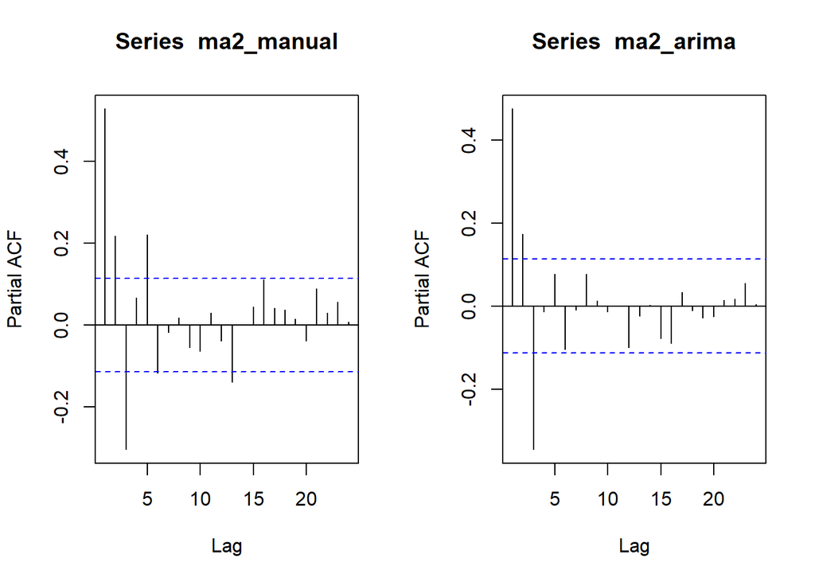

```r
par(mfrow = c(1, 2))
pacf(ma2_manual)
pacf(ma2_arima)
```

Berdasarkan plot PACF, terlihat bahwa plot PACF cenderung tails off. Terdapat beberapa spike yang melewati batas signifikansi pada beberapa lag awal, kemudian sebagian besar nilai PACF berada di dalam batas signifikansi. Pola tails off ini sesuai dengan karakteristik model MA(2).

### Plot EACF

```r
TSA::eacf(ma2_manual)
```

```
## AR/MA
##   0 1 2 3 4 5 6 7 8 9 10 11 12 13
## 0 x x o o o o o o o o o  o  x  x
## 1 x x x o o o o o o o o  o  o  o
## 2 x x x x o o o o o o o  o  o  o
## 3 x x x x x o o o o o o  o  o  o
## 4 x x x x x o o o o o o  o  o  o
## 5 x x o x x o x o o o o  o  o  o
## 6 x x x o x o o x o o o  o  o  o
## 7 x o x o x o o x o o o  o  o  o
```

```r
TSA::eacf(ma2_arima)
```

```
## AR/MA
##   0 1 2 3 4 5 6 7 8 9 10 11 12 13
## 0 x x o o x x o o o o o  o  o  o
## 1 x x x o o o o o o o o  o  o  o
## 2 x x x o o o o o o o o  o  o  o
## 3 o x x x o o o o o o o  o  o  o
## 4 x o x x x o o o o o o  o  o  o
## 5 x x x x x x o o o o o  o  o  o
## 6 o x x x o o o o o o o  o  o  o
## 7 x x x x o o o o o o o  o  o  o
```

Berdasarkan pola segitiga nol pada plot EACF, terlihat bahwa segitiga nol berada pada ordo ar(0) dan ordo MA(2)

### Kesimpulan

Berdasarkan hasil plot time series, ACF, PACF, dan EACF dapat disimpulkan bahwa data MA(2) **bersifat stasioner** karena pada plot time series data berfluktuasi di sekitar nilai rata-rata yang relatif konstan dan tidak menunjukkan tren yang jelas. Plot ACF *cuts off* pada lag kedua, Plot PACF mengalami *tails off*. Sementara itu, pola segitiga nol pada EACF menunjukkan ordo ar(0) dan MA(2), sehingga model yang sesuai adalah MA(2) atau AR(0,2)

## Scatterplot & Auto korelasi Antar Lag

### Yt dengan Yt−1

#### Plot

```r
par(mfrow = c(1, 2))
#Yt
yt_ma2_manual <- ma2_manual[-1]
yt_ma2_manual
```

```
##   [1] -0.205397058  0.471173424 -1.745463687  0.141510314 -0.729712854
##   [6] -0.114842790 -0.472894305 -1.127948717 -1.443797742 -1.171879031
##  [11] -1.723286222 -1.461924092 -0.845074607  0.519525249  0.312187420
##  [16]  0.020572732 -1.181770516 -1.508255550  1.534249256  0.598119283
##  [21]  1.012450498 -0.556369299 -0.011041246 -0.774213194 -1.449939345
##  [26] -0.420758391 -1.662676381 -0.079747157 -1.556197355  0.718835126
##  [31] -0.596243221 -0.238298741 -1.070389923 -2.255260716 -2.120011486
##  [36] -3.624543435 -2.913580609 -2.138714925 -1.388210999  1.086560934
##  [41] -0.768382742 -0.413123964 -1.263954490 -1.619808057 -1.534624150
##  [46] -2.091327966 -2.276021753 -1.689013389 -1.457572736 -2.319068111
##  [51] -1.602598402 -2.425338748 -1.807763414 -1.233628102 -0.110845196
##  [56]  1.775654086  0.223607057  2.285258743 -0.979456751  1.157010823
##  [61]  2.116941328  1.378789117  0.845856907 -0.296314421  1.372262398
##  [66] -0.432336811  1.978634754  1.193531021  1.688995021  0.939220832
##  [71] -0.250827924 -0.544575725  0.228395751  2.109671129  1.063681873
```

[output cut: 45 more lines]

```r
#Yt-1
yt_1_ma2_manual <- ma2_manual[-300]
yt_1_ma2_manual
```

```
##   [1] -1.207065749 -0.205397058  0.471173424 -1.745463687  0.141510314
##   [6] -0.729712854 -0.114842790 -0.472894305 -1.127948717 -1.443797742
##  [11] -1.171879031 -1.723286222 -1.461924092 -0.845074607  0.519525249
##  [16]  0.312187420  0.020572732 -1.181770516 -1.508255550  1.534249256
##  [21]  0.598119283  1.012450498 -0.556369299 -0.011041246 -0.774213194
##  [26] -1.449939345 -0.420758391 -1.662676381 -0.079747157 -1.556197355
##  [31]  0.718835126 -0.596243221 -0.238298741 -1.070389923 -2.255260716
##  [36] -2.120011486 -3.624543435 -2.913580609 -2.138714925 -1.388210999
##  [41]  1.086560934 -0.768382742 -0.413123964 -1.263954490 -1.619808057
##  [46] -1.534624150 -2.091327966 -2.276021753 -1.689013389 -1.457572736
##  [51] -2.319068111 -1.602598402 -2.425338748 -1.807763414 -1.233628102
##  [56] -0.110845196  1.775654086  0.223607057  2.285258743 -0.979456751
##  [61]  1.157010823  2.116941328  1.378789117  0.845856907 -0.296314421
##  [66]  1.372262398 -0.432336811  1.978634754  1.193531021  1.688995021
##  [71]  0.939220832 -0.250827924 -0.544575725  0.228395751  2.109671129
```

[output cut: 45 more lines]

```r
plot(y=yt_ma2_manual,x=yt_1_ma2_manual)

#Yt
yt_ma2_arima <- ma2_arima[-1]
yt_ma2_arima
```

```
##   [1]  0.366069559  0.319892749 -0.033692645 -0.749809541  1.023224875
##   [6] -0.103827746  1.553027734  1.508813504  1.490258435  0.638775303
##  [11]  0.057508568 -0.761313741  1.006804154  0.046165301  2.226792228
##  [16] -0.031351321  0.058227766 -0.452682262 -0.306828839 -0.408896770
##  [21] -1.768664231 -0.905163217 -1.653388217  0.814020129 -0.949587092
##  [26]  1.394975120 -0.770061199  0.708742509  0.626264945  0.016220780
##  [31]  0.886163244 -0.177443664 -0.837739266 -0.776948985  0.830630275
##  [36]  0.271737011  0.068438994 -0.509614613 -0.182137038  1.054967504
##  [41]  1.724174690  1.131301118  1.891160132 -0.238116411 -1.951472236
##  [46] -1.868044756 -2.111236903 -2.805388403 -0.673455997 -1.948408128
##  [51] -0.202080988 -2.147789666 -0.222949385  1.157974906  0.206928218
##  [56]  0.670946455  1.376843234  1.645766212  3.455813794  1.320279510
##  [61]  0.993481981 -0.573676112  1.139365011 -1.017788045  0.653723024
##  [66] -0.694895967  2.417702916  0.264911871 -0.401396581 -0.735903736
##  [71] -0.852168890 -0.715405484 -0.227148156 -0.726083352 -0.709593887
```

[output cut: 45 more lines]

```r
#Yt-1
yt_1_ma2_arima <- ma2_arima[-300]
yt_1_ma2_arima
```

```
##   [1] -0.908714261  0.366069559  0.319892749 -0.033692645 -0.749809541
##   [6]  1.023224875 -0.103827746  1.553027734  1.508813504  1.490258435
##  [11]  0.638775303  0.057508568 -0.761313741  1.006804154  0.046165301
##  [16]  2.226792228 -0.031351321  0.058227766 -0.452682262 -0.306828839
##  [21] -0.408896770 -1.768664231 -0.905163217 -1.653388217  0.814020129
##  [26] -0.949587092  1.394975120 -0.770061199  0.708742509  0.626264945
##  [31]  0.016220780  0.886163244 -0.177443664 -0.837739266 -0.776948985
##  [36]  0.830630275  0.271737011  0.068438994 -0.509614613 -0.182137038
##  [41]  1.054967504  1.724174690  1.131301118  1.891160132 -0.238116411
##  [46] -1.951472236 -1.868044756 -2.111236903 -2.805388403 -0.673455997
##  [51] -1.948408128 -0.202080988 -2.147789666 -0.222949385  1.157974906
##  [56]  0.206928218  0.670946455  1.376843234  1.645766212  3.455813794
##  [61]  1.320279510  0.993481981 -0.573676112  1.139365011 -1.017788045
##  [66]  0.653723024 -0.694895967  2.417702916  0.264911871 -0.401396581
##  [71] -0.735903736 -0.852168890 -0.715405484 -0.227148156 -0.726083352
```

[output cut: 45 more lines]

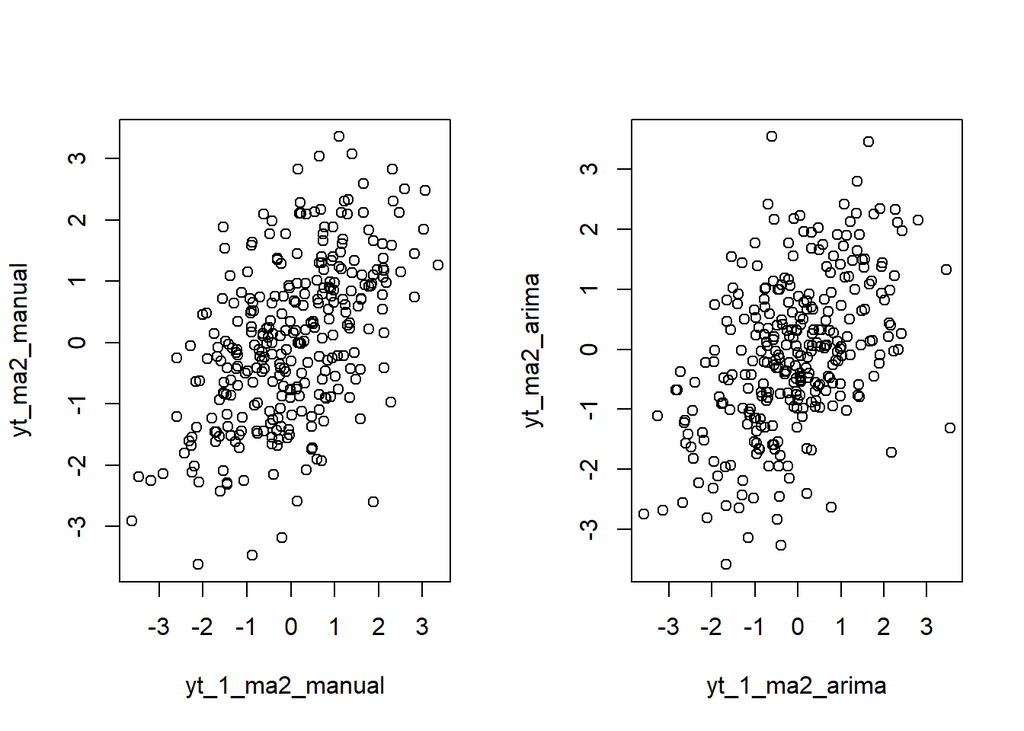

```r
plot(y=yt_ma2_arima,x=yt_1_ma2_arima)
```

#### Korelasi

```r
cor(yt_ma2_manual,yt_1_ma2_manual)
```

```
## [1] 0.5282201
```

```r
cor(yt_ma2_arima,yt_1_ma2_arima)
```

```
## [1] 0.4750929
```

Korelasi antara Yt dengan Yt−1 dari hasil simulasi mendekati perhitungan teoritis yaitu
$$\rho_1=\frac{0.4+(0.4)(0.6)}{1+(0.4)^2+(0.6)^2}
=\frac{0.64}{1.52}
=0.421$$

### Yt dengan Yt−2

#### Plot

```r
par(mfrow = c(1, 2))
#Yt
yt_ma2_manual_lag2 <- ma2_manual[-c(1,2)]
yt_ma2_manual_lag2
```

```
##   [1]  0.471173424 -1.745463687  0.141510314 -0.729712854 -0.114842790
##   [6] -0.472894305 -1.127948717 -1.443797742 -1.171879031 -1.723286222
##  [11] -1.461924092 -0.845074607  0.519525249  0.312187420  0.020572732
##  [16] -1.181770516 -1.508255550  1.534249256  0.598119283  1.012450498
##  [21] -0.556369299 -0.011041246 -0.774213194 -1.449939345 -0.420758391
##  [26] -1.662676381 -0.079747157 -1.556197355  0.718835126 -0.596243221
##  [31] -0.238298741 -1.070389923 -2.255260716 -2.120011486 -3.624543435
##  [36] -2.913580609 -2.138714925 -1.388210999  1.086560934 -0.768382742
##  [41] -0.413123964 -1.263954490 -1.619808057 -1.534624150 -2.091327966
##  [46] -2.276021753 -1.689013389 -1.457572736 -2.319068111 -1.602598402
##  [51] -2.425338748 -1.807763414 -1.233628102 -0.110845196  1.775654086
##  [56]  0.223607057  2.285258743 -0.979456751  1.157010823  2.116941328
##  [61]  1.378789117  0.845856907 -0.296314421  1.372262398 -0.432336811
##  [66]  1.978634754  1.193531021  1.688995021  0.939220832 -0.250827924
##  [71] -0.544575725  0.228395751  2.109671129  1.063681873 -0.209897795
```

[output cut: 45 more lines]

```r
# Yt-2
yt_2_ma2_manual <- ma2_manual[-c(299, 300)]
yt_2_ma2_manual
```

```
##   [1] -1.207065749 -0.205397058  0.471173424 -1.745463687  0.141510314
##   [6] -0.729712854 -0.114842790 -0.472894305 -1.127948717 -1.443797742
##  [11] -1.171879031 -1.723286222 -1.461924092 -0.845074607  0.519525249
##  [16]  0.312187420  0.020572732 -1.181770516 -1.508255550  1.534249256
##  [21]  0.598119283  1.012450498 -0.556369299 -0.011041246 -0.774213194
##  [26] -1.449939345 -0.420758391 -1.662676381 -0.079747157 -1.556197355
##  [31]  0.718835126 -0.596243221 -0.238298741 -1.070389923 -2.255260716
##  [36] -2.120011486 -3.624543435 -2.913580609 -2.138714925 -1.388210999
##  [41]  1.086560934 -0.768382742 -0.413123964 -1.263954490 -1.619808057
##  [46] -1.534624150 -2.091327966 -2.276021753 -1.689013389 -1.457572736
##  [51] -2.319068111 -1.602598402 -2.425338748 -1.807763414 -1.233628102
##  [56] -0.110845196  1.775654086  0.223607057  2.285258743 -0.979456751
##  [61]  1.157010823  2.116941328  1.378789117  0.845856907 -0.296314421
##  [66]  1.372262398 -0.432336811  1.978634754  1.193531021  1.688995021
##  [71]  0.939220832 -0.250827924 -0.544575725  0.228395751  2.109671129
```

[output cut: 45 more lines]

```r
plot(y=yt_ma2_manual_lag2,x=yt_2_ma2_manual)

#Yt
yt_ma2_arima_lag2 <- ma2_arima[-c(1,2)]
yt_ma2_arima_lag2
```

```
##   [1]  0.319892749 -0.033692645 -0.749809541  1.023224875 -0.103827746
##   [6]  1.553027734  1.508813504  1.490258435  0.638775303  0.057508568
##  [11] -0.761313741  1.006804154  0.046165301  2.226792228 -0.031351321
##  [16]  0.058227766 -0.452682262 -0.306828839 -0.408896770 -1.768664231
##  [21] -0.905163217 -1.653388217  0.814020129 -0.949587092  1.394975120
##  [26] -0.770061199  0.708742509  0.626264945  0.016220780  0.886163244
##  [31] -0.177443664 -0.837739266 -0.776948985  0.830630275  0.271737011
##  [36]  0.068438994 -0.509614613 -0.182137038  1.054967504  1.724174690
##  [41]  1.131301118  1.891160132 -0.238116411 -1.951472236 -1.868044756
##  [46] -2.111236903 -2.805388403 -0.673455997 -1.948408128 -0.202080988
##  [51] -2.147789666 -0.222949385  1.157974906  0.206928218  0.670946455
##  [56]  1.376843234  1.645766212  3.455813794  1.320279510  0.993481981
##  [61] -0.573676112  1.139365011 -1.017788045  0.653723024 -0.694895967
##  [66]  2.417702916  0.264911871 -0.401396581 -0.735903736 -0.852168890
##  [71] -0.715405484 -0.227148156 -0.726083352 -0.709593887  0.064017627
```

[output cut: 45 more lines]

```r
# Yt-2
yt_2_ma2_arima <- ma2_arima[-c(299, 300)]
yt_2_ma2_arima
```

```
##   [1] -0.908714261  0.366069559  0.319892749 -0.033692645 -0.749809541
##   [6]  1.023224875 -0.103827746  1.553027734  1.508813504  1.490258435
##  [11]  0.638775303  0.057508568 -0.761313741  1.006804154  0.046165301
##  [16]  2.226792228 -0.031351321  0.058227766 -0.452682262 -0.306828839
##  [21] -0.408896770 -1.768664231 -0.905163217 -1.653388217  0.814020129
##  [26] -0.949587092  1.394975120 -0.770061199  0.708742509  0.626264945
##  [31]  0.016220780  0.886163244 -0.177443664 -0.837739266 -0.776948985
##  [36]  0.830630275  0.271737011  0.068438994 -0.509614613 -0.182137038
##  [41]  1.054967504  1.724174690  1.131301118  1.891160132 -0.238116411
##  [46] -1.951472236 -1.868044756 -2.111236903 -2.805388403 -0.673455997
##  [51] -1.948408128 -0.202080988 -2.147789666 -0.222949385  1.157974906
##  [56]  0.206928218  0.670946455  1.376843234  1.645766212  3.455813794
##  [61]  1.320279510  0.993481981 -0.573676112  1.139365011 -1.017788045
##  [66]  0.653723024 -0.694895967  2.417702916  0.264911871 -0.401396581
##  [71] -0.735903736 -0.852168890 -0.715405484 -0.227148156 -0.726083352
```

[output cut: 45 more lines]

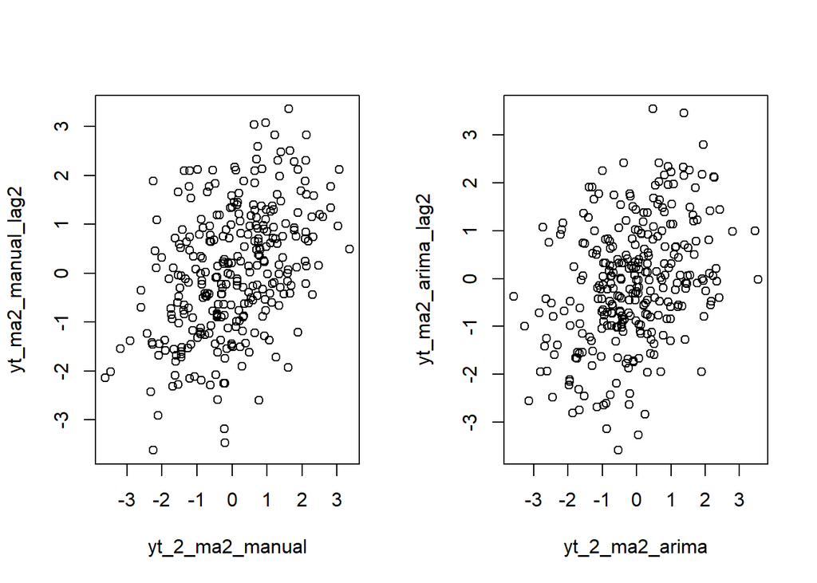

```r
plot(y=yt_ma2_arima_lag2,x=yt_2_ma2_arima)
```

#### Korelasi

```r
cor(yt_ma2_manual_lag2,yt_2_ma2_manual)
```

```
## [1] 0.4356204
```

```r
cor(yt_ma2_arima_lag2,yt_2_ma2_arima)
```

```
## [1] 0.3599318
```

Korelasi antara Yt dengan Yt−2 dari hasil simulasi mendekati perhitungan teoritis yaitu
$$\rho_2=\frac{(0.6)}{1+(0.4)^2+(0.6)^2}
=\frac{0.6}{1.52}
=0.3947$$

### Yt dengan Yt−3

#### Plot

```r
par(mfrow = c(1, 2))
#Yt
yt_ma2_manual_lag3 <- ma2_manual[-c(1,2,3)]
yt_ma2_manual_lag3
```

```
##   [1] -1.745463687  0.141510314 -0.729712854 -0.114842790 -0.472894305
##   [6] -1.127948717 -1.443797742 -1.171879031 -1.723286222 -1.461924092
##  [11] -0.845074607  0.519525249  0.312187420  0.020572732 -1.181770516
##  [16] -1.508255550  1.534249256  0.598119283  1.012450498 -0.556369299
##  [21] -0.011041246 -0.774213194 -1.449939345 -0.420758391 -1.662676381
##  [26] -0.079747157 -1.556197355  0.718835126 -0.596243221 -0.238298741
##  [31] -1.070389923 -2.255260716 -2.120011486 -3.624543435 -2.913580609
##  [36] -2.138714925 -1.388210999  1.086560934 -0.768382742 -0.413123964
##  [41] -1.263954490 -1.619808057 -1.534624150 -2.091327966 -2.276021753
##  [46] -1.689013389 -1.457572736 -2.319068111 -1.602598402 -2.425338748
##  [51] -1.807763414 -1.233628102 -0.110845196  1.775654086  0.223607057
##  [56]  2.285258743 -0.979456751  1.157010823  2.116941328  1.378789117
##  [61]  0.845856907 -0.296314421  1.372262398 -0.432336811  1.978634754
##  [66]  1.193531021  1.688995021  0.939220832 -0.250827924 -0.544575725
##  [71]  0.228395751  2.109671129  1.063681873 -0.209897795 -1.371901203
```

[output cut: 45 more lines]

```r
# Yt-3
yt_3_ma2_manual <- ma2_manual[-c(298,299, 300)]
yt_3_ma2_manual
```

```
##   [1] -1.207065749 -0.205397058  0.471173424 -1.745463687  0.141510314
##   [6] -0.729712854 -0.114842790 -0.472894305 -1.127948717 -1.443797742
##  [11] -1.171879031 -1.723286222 -1.461924092 -0.845074607  0.519525249
##  [16]  0.312187420  0.020572732 -1.181770516 -1.508255550  1.534249256
##  [21]  0.598119283  1.012450498 -0.556369299 -0.011041246 -0.774213194
##  [26] -1.449939345 -0.420758391 -1.662676381 -0.079747157 -1.556197355
##  [31]  0.718835126 -0.596243221 -0.238298741 -1.070389923 -2.255260716
##  [36] -2.120011486 -3.624543435 -2.913580609 -2.138714925 -1.388210999
##  [41]  1.086560934 -0.768382742 -0.413123964 -1.263954490 -1.619808057
##  [46] -1.534624150 -2.091327966 -2.276021753 -1.689013389 -1.457572736
##  [51] -2.319068111 -1.602598402 -2.425338748 -1.807763414 -1.233628102
##  [56] -0.110845196  1.775654086  0.223607057  2.285258743 -0.979456751
##  [61]  1.157010823  2.116941328  1.378789117  0.845856907 -0.296314421
##  [66]  1.372262398 -0.432336811  1.978634754  1.193531021  1.688995021
##  [71]  0.939220832 -0.250827924 -0.544575725  0.228395751  2.109671129
```

[output cut: 45 more lines]

```r
plot(y=yt_ma2_manual_lag3,x=yt_3_ma2_manual)

#Yt
yt_ma2_arima_lag3 <- ma2_arima[-c(1,2,3)]
yt_ma2_arima_lag3
```

```
##   [1] -0.033692645 -0.749809541  1.023224875 -0.103827746  1.553027734
##   [6]  1.508813504  1.490258435  0.638775303  0.057508568 -0.761313741
##  [11]  1.006804154  0.046165301  2.226792228 -0.031351321  0.058227766
##  [16] -0.452682262 -0.306828839 -0.408896770 -1.768664231 -0.905163217
##  [21] -1.653388217  0.814020129 -0.949587092  1.394975120 -0.770061199
##  [26]  0.708742509  0.626264945  0.016220780  0.886163244 -0.177443664
##  [31] -0.837739266 -0.776948985  0.830630275  0.271737011  0.068438994
##  [36] -0.509614613 -0.182137038  1.054967504  1.724174690  1.131301118
##  [41]  1.891160132 -0.238116411 -1.951472236 -1.868044756 -2.111236903
##  [46] -2.805388403 -0.673455997 -1.948408128 -0.202080988 -2.147789666
##  [51] -0.222949385  1.157974906  0.206928218  0.670946455  1.376843234
##  [56]  1.645766212  3.455813794  1.320279510  0.993481981 -0.573676112
##  [61]  1.139365011 -1.017788045  0.653723024 -0.694895967  2.417702916
##  [66]  0.264911871 -0.401396581 -0.735903736 -0.852168890 -0.715405484
##  [71] -0.227148156 -0.726083352 -0.709593887  0.064017627 -0.538583124
```

[output cut: 45 more lines]

```r
# Yt-3
yt_3_ma2_arima <- ma2_arima[-c(298,299, 300)]
yt_3_ma2_arima
```

```
##   [1] -0.908714261  0.366069559  0.319892749 -0.033692645 -0.749809541
##   [6]  1.023224875 -0.103827746  1.553027734  1.508813504  1.490258435
##  [11]  0.638775303  0.057508568 -0.761313741  1.006804154  0.046165301
##  [16]  2.226792228 -0.031351321  0.058227766 -0.452682262 -0.306828839
##  [21] -0.408896770 -1.768664231 -0.905163217 -1.653388217  0.814020129
##  [26] -0.949587092  1.394975120 -0.770061199  0.708742509  0.626264945
##  [31]  0.016220780  0.886163244 -0.177443664 -0.837739266 -0.776948985
##  [36]  0.830630275  0.271737011  0.068438994 -0.509614613 -0.182137038
##  [41]  1.054967504  1.724174690  1.131301118  1.891160132 -0.238116411
##  [46] -1.951472236 -1.868044756 -2.111236903 -2.805388403 -0.673455997
##  [51] -1.948408128 -0.202080988 -2.147789666 -0.222949385  1.157974906
##  [56]  0.206928218  0.670946455  1.376843234  1.645766212  3.455813794
##  [61]  1.320279510  0.993481981 -0.573676112  1.139365011 -1.017788045
##  [66]  0.653723024 -0.694895967  2.417702916  0.264911871 -0.401396581
##  [71] -0.735903736 -0.852168890 -0.715405484 -0.227148156 -0.726083352
```

[output cut: 45 more lines]

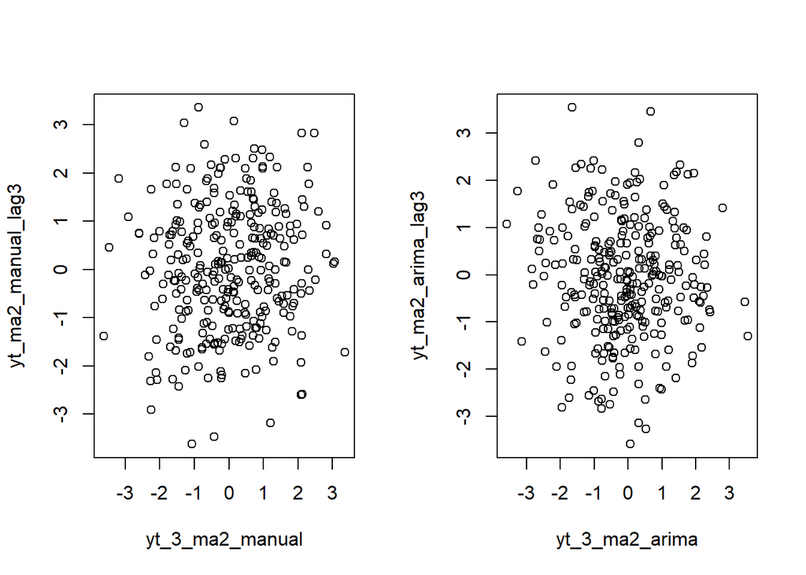

```r
plot(y=yt_ma2_arima_lag3,x=yt_3_ma2_arima)
```

#### Korelasi

```r
cor(yt_ma2_manual_lag3,yt_3_ma2_manual)
```

```
## [1] 0.08544546
```

```r
cor(yt_ma2_arima_lag3,yt_3_ma2_manual)
```

```
## [1] -0.0296439
```

# Proses ar(2)

Membangkitkan Model ar(2)  
Dalam kasus ini, akan dibangkitkan suatu data dengan model ar(2) sebanyak 300 data yang memiliki nilai ϕ1=0.5 dan ϕ2=0.2. Rumusan model tersebut adalah sebagai berikut

$Y_t = \varepsilon_t + 0.5Y_{t-1} + 0.2Y_{t-2}$

## Membangkitkan Model AR(2)

### Manual

```r
set.seed(1051)
n<-length(wn)
n
```

```
## [1] 300
```

```r
ar2_manual <- c(1:n)
ar2_manual[1] <- wn[1]
ar2_manual[2] <- wn[2] + 0.5 * ar2_manual[1]
for (i in 3:n) {
  ar2_manual[i] <- wn[i] + 0.5 * ar2_manual[i-1] + 0.2 * ar2_manual[i-2]
}
ar2_manual
```

```
##   [1] -1.207065749 -0.326103633  0.679976211 -2.070930324 -0.470345231
##   [6] -0.143302788 -0.740460400 -0.945522614 -1.185305386 -1.671795045
##  [11] -1.550151299 -2.107821103 -2.140194706 -1.427202757 -0.182146261
##  [16] -0.486799176 -0.790838346 -1.403974425 -1.697326562  1.286377013
##  [21]  0.437811414 -0.014504787 -0.360237983  0.276569492 -0.627483098
##  [26] -1.706632561 -0.404057179 -1.567010825 -0.879455148 -1.689078340
##  [31]  0.081867346 -0.772475074 -1.079304105 -1.195405128 -2.442656854
##  [36] -2.628028715 -3.982585377 -3.857891624 -3.019756746 -2.747354238
##  [41] -0.528132203 -1.882179673 -1.902080911 -1.608099392 -2.178805954
##  [46] -2.379537173 -2.732847970 -3.094317305 -2.617556366 -2.424491601
##  [51] -3.541788331 -2.837868410 -3.236181496 -3.200626439 -2.409859042
##  [56] -1.281998990  0.524846169 -0.767330137  1.327213794 -0.647667678
##  [61]  0.598197384  2.718556227  1.444157201  0.596156266  0.579304817
##  [66]  2.185968110  0.070237282  1.840139442  2.263681968  1.836341670
##  [71]  1.377800067  0.600699629  0.209385895  0.873119441  2.548707761
```

[output cut: 45 more lines]

### arima.sim

```r
ar2_arima <- arima.sim(list(order=c(2,0,0), ar=c(0.5,0.2)), n=300)
ar2_arima
```

```
## Time Series:
## Start = 1
## End = 300
## Frequency = 1
##   [1]  1.172148447 -0.437733455 -1.926194858 -1.784562216 -2.074856748
##   [6] -0.603346856  0.115336517  1.979928265  0.519205299 -0.696176184
##  [11] -1.468891852 -1.927645533 -0.617721121 -3.073969845 -1.105255535
##  [16] -1.544078453 -0.780667738 -1.441119681 -2.237546251 -1.120567457
##  [21] -2.338668243 -1.598298743 -1.702689791 -2.250655081 -2.969989827
##  [26] -1.661653202 -0.190403943  0.288746608  0.192231777 -0.568477298
##  [31] -2.040429169 -1.485135159 -0.811636997 -0.443239566  0.675068462
##  [36]  1.054017939  2.125241038 -0.883076182 -1.671984404 -2.580559885
##  [41] -2.313009738 -1.734646274 -2.008357108 -0.008284272 -1.275232709
##  [46] -1.213701396 -0.652328651 -0.555429203  0.665476831  0.487308486
##  [51] -1.231349306 -1.620098695 -1.397786958 -0.680197409 -0.629349571
```

[output cut: 49 more lines]

## Karakteristik AR (2)

### Plot Time Series

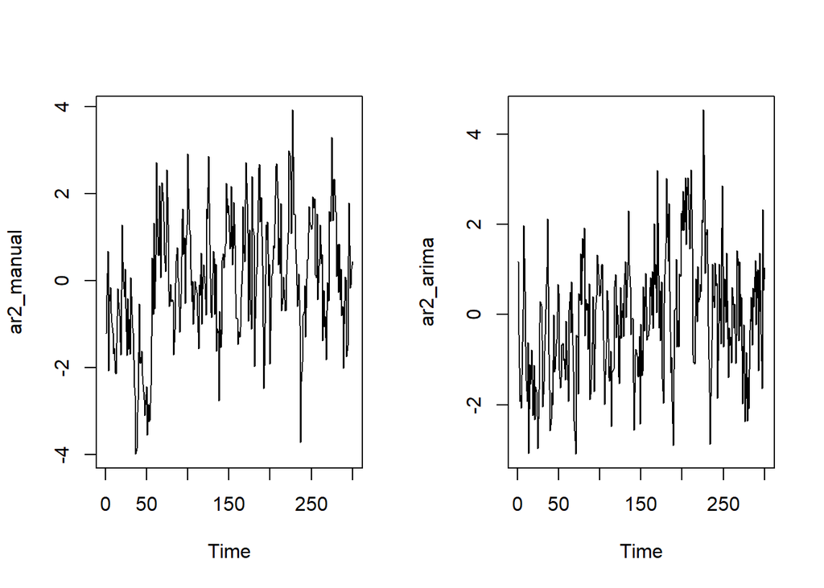

```r
par(mfrow = c(1, 2))
ts.plot(ar2_manual)
ts.plot(ar2_arima)
```

Berdasarkan plot time series tersebut terlihat bahwa data cenderung stasioner pada rataan

### Plot ACF

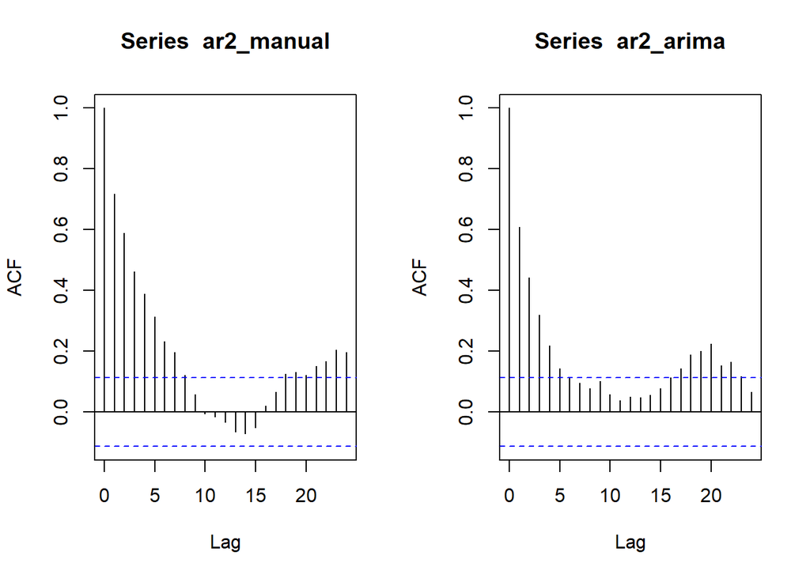

```r
par(mfrow = c(1, 2))
acf(ar2_manual)
acf(ar2_arima)
```

Berdasarkan plot ACF, terlihat bahwa nilai autokorelasi cenderung tails off, yaitu menurun secara bertahap menuju nol, kemudian berfluktuasi di sekitar nol dan membentuk pola osilasi pada beberapa lag berikutnya.

### Plot PACF

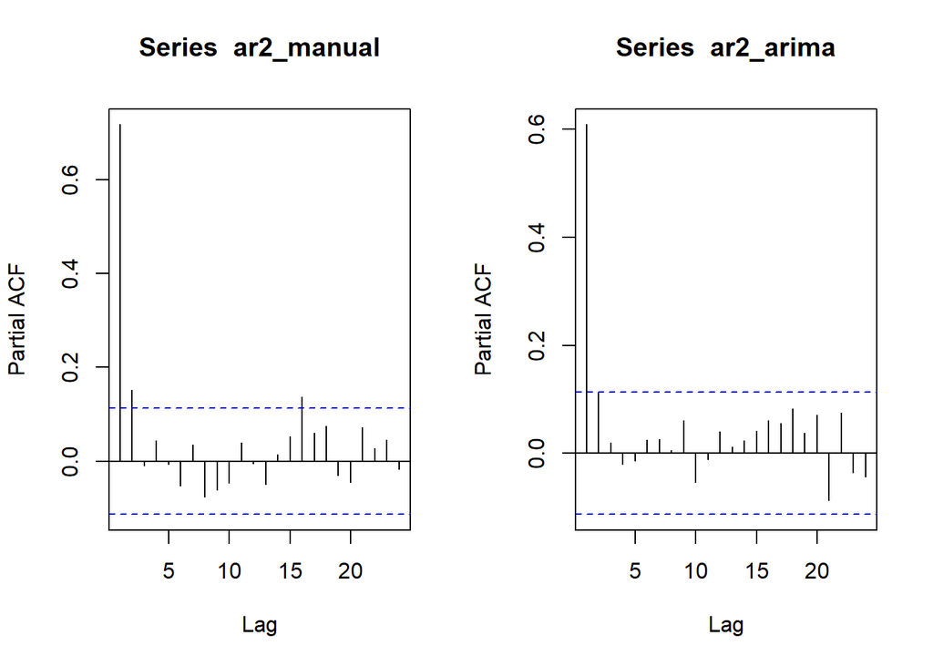

```r
par(mfrow = c(1, 2))
pacf(ar2_manual)
pacf(ar2_arima)
```

### Plot EACF

```r
TSA::eacf(ar2_manual)
```

```
## AR/MA
##   0 1 2 3 4 5 6 7 8 9 10 11 12 13
## 0 x x x x x x x x o o o  o  o  o
## 1 x o o o o o o o o o o  o  o  o
## 2 o o o o o o o o o o o  o  o  o
## 3 x x o o o o o o o o o  o  o  o
## 4 x x o o o o o o o o o  o  o  o
## 5 o x o x o o x o o o o  o  o  o
## 6 x x x x o o o o o o o  o  o  o
## 7 x x x o x x o o o o o  o  o  o
```

```r
TSA::eacf(ar2_arima)
```

```
## AR/MA
##   0 1 2 3 4 5 6 7 8 9 10 11 12 13
## 0 x x x x x o o o o o o  o  o  o
## 1 x o o o o o o o o o o  o  o  o
## 2 x o o o o o o o o o o  o  o  o
## 3 x x o o o o o o o o o  o  o  o
## 4 x x o o o o o o o o o  o  o  o
## 5 x x x o o o o o o o o  o  o  o
## 6 x x o o o o o o o o o  o  o  o
## 7 x x o x o o o o o o o  o  o  o
```

## Scatterplot & Auto korelasi Antar Lag

### Yt dengan Yt−1

#### Plot

```r
par(mfrow = c(1, 2))
#Yt
yt_ar2_manual <- ar2_manual[-1]
yt_ar2_manual
```

```
##   [1] -0.326103633  0.679976211 -2.070930324 -0.470345231 -0.143302788
##   [6] -0.740460400 -0.945522614 -1.185305386 -1.671795045 -1.550151299
##  [11] -2.107821103 -2.140194706 -1.427202757 -0.182146261 -0.486799176
##  [16] -0.790838346 -1.403974425 -1.697326562  1.286377013  0.437811414
##  [21] -0.014504787 -0.360237983  0.276569492 -0.627483098 -1.706632561
##  [26] -0.404057179 -1.567010825 -0.879455148 -1.689078340  0.081867346
##  [31] -0.772475074 -1.079304105 -1.195405128 -2.442656854 -2.628028715
##  [36] -3.982585377 -3.857891624 -3.019756746 -2.747354238 -0.528132203
##  [41] -1.882179673 -1.902080911 -1.608099392 -2.178805954 -2.379537173
##  [46] -2.732847970 -3.094317305 -2.617556366 -2.424491601 -3.541788331
##  [51] -2.837868410 -3.236181496 -3.200626439 -2.409859042 -1.281998990
##  [56]  0.524846169 -0.767330137  1.327213794 -0.647667678  0.598197384
##  [61]  2.718556227  1.444157201  0.596156266  0.579304817  2.185968110
##  [66]  0.070237282  1.840139442  2.263681968  1.836341670  1.377800067
##  [71]  0.600699629  0.209385895  0.873119441  2.548707761  1.295579356
```

[output cut: 45 more lines]

```r
#Yt-1
yt_1_ar2_manual <- ar2_manual[-300]
yt_1_ar2_manual
```

```
##   [1] -1.207065749 -0.326103633  0.679976211 -2.070930324 -0.470345231
##   [6] -0.143302788 -0.740460400 -0.945522614 -1.185305386 -1.671795045
##  [11] -1.550151299 -2.107821103 -2.140194706 -1.427202757 -0.182146261
##  [16] -0.486799176 -0.790838346 -1.403974425 -1.697326562  1.286377013
##  [21]  0.437811414 -0.014504787 -0.360237983  0.276569492 -0.627483098
##  [26] -1.706632561 -0.404057179 -1.567010825 -0.879455148 -1.689078340
##  [31]  0.081867346 -0.772475074 -1.079304105 -1.195405128 -2.442656854
##  [36] -2.628028715 -3.982585377 -3.857891624 -3.019756746 -2.747354238
##  [41] -0.528132203 -1.882179673 -1.902080911 -1.608099392 -2.178805954
##  [46] -2.379537173 -2.732847970 -3.094317305 -2.617556366 -2.424491601
##  [51] -3.541788331 -2.837868410 -3.236181496 -3.200626439 -2.409859042
##  [56] -1.281998990  0.524846169 -0.767330137  1.327213794 -0.647667678
##  [61]  0.598197384  2.718556227  1.444157201  0.596156266  0.579304817
##  [66]  2.185968110  0.070237282  1.840139442  2.263681968  1.836341670
##  [71]  1.377800067  0.600699629  0.209385895  0.873119441  2.548707761
```

[output cut: 45 more lines]

```r
plot(y=yt_ar2_manual,x=yt_1_ar2_manual)

#Yt
yt_ar2_arima <- ar2_arima[-1]
yt_ar2_arima
```

```
##   [1] -0.437733455 -1.926194858 -1.784562216 -2.074856748 -0.603346856
##   [6]  0.115336517  1.979928265  0.519205299 -0.696176184 -1.468891852
##  [11] -1.927645533 -0.617721121 -3.073969845 -1.105255535 -1.544078453
##  [16] -0.780667738 -1.441119681 -2.237546251 -1.120567457 -2.338668243
##  [21] -1.598298743 -1.702689791 -2.250655081 -2.969989827 -1.661653202
##  [26] -0.190403943  0.288746608  0.192231777 -0.568477298 -2.040429169
##  [31] -1.485135159 -0.811636997 -0.443239566  0.675068462  1.054017939
##  [36]  2.125241038 -0.883076182 -1.671984404 -2.580559885 -2.313009738
##  [41] -1.734646274 -2.008357108 -0.008284272 -1.275232709 -1.213701396
##  [46] -0.652328651 -0.555429203  0.665476831  0.487308486 -1.231349306
##  [51] -1.620098695 -1.397786958 -0.680197409 -0.629349571 -1.020774866
##  [56] -0.975089143 -1.448311341 -0.144248036 -0.782066972 -1.452734085
##  [61] -1.920048812  0.106817503  0.488751193 -0.405237469  0.730079241
##  [66] -0.674487846 -1.261319914 -2.357243530 -2.798441847 -3.095940472
##  [71] -0.462035605 -0.500110261 -1.767886587  0.460671138  0.318425904
```

[output cut: 45 more lines]

```r
#Yt-1
yt_1_ar2_arima <- ar2_arima[-300]
yt_1_ar2_arima
```

```
##   [1]  1.172148447 -0.437733455 -1.926194858 -1.784562216 -2.074856748
##   [6] -0.603346856  0.115336517  1.979928265  0.519205299 -0.696176184
##  [11] -1.468891852 -1.927645533 -0.617721121 -3.073969845 -1.105255535
##  [16] -1.544078453 -0.780667738 -1.441119681 -2.237546251 -1.120567457
##  [21] -2.338668243 -1.598298743 -1.702689791 -2.250655081 -2.969989827
##  [26] -1.661653202 -0.190403943  0.288746608  0.192231777 -0.568477298
##  [31] -2.040429169 -1.485135159 -0.811636997 -0.443239566  0.675068462
##  [36]  1.054017939  2.125241038 -0.883076182 -1.671984404 -2.580559885
##  [41] -2.313009738 -1.734646274 -2.008357108 -0.008284272 -1.275232709
##  [46] -1.213701396 -0.652328651 -0.555429203  0.665476831  0.487308486
##  [51] -1.231349306 -1.620098695 -1.397786958 -0.680197409 -0.629349571
##  [56] -1.020774866 -0.975089143 -1.448311341 -0.144248036 -0.782066972
##  [61] -1.452734085 -1.920048812  0.106817503  0.488751193 -0.405237469
##  [66]  0.730079241 -0.674487846 -1.261319914 -2.357243530 -2.798441847
##  [71] -3.095940472 -0.462035605 -0.500110261 -1.767886587  0.460671138
```

[output cut: 45 more lines]

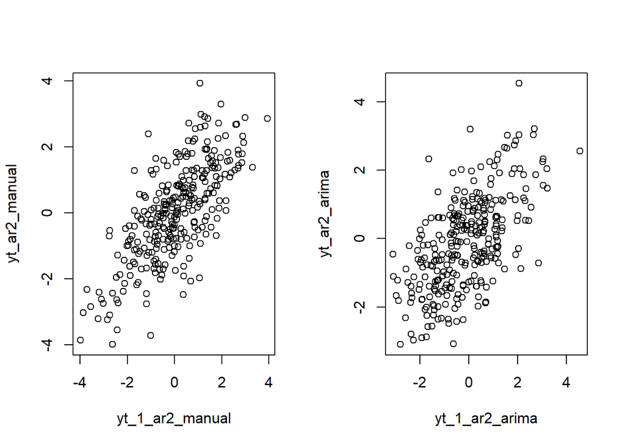

```r
plot(y=yt_ar2_arima,x=yt_1_ar2_arima)
```

Berdasarkan scatterplot tersebut, terlihat bahwa terdapat hubungan positif antara Yt dengan Yt−1. Hal ini sesuai dengan teori yang ada

#### Korelasi

```r
cor(yt_ar2_manual,yt_1_ar2_manual)
```

```
## [1] 0.7181941
```

```r
cor(yt_ar2_arima,yt_1_ar2_arima)
```

```
## [1] 0.6107015
```

Korelasi antara Yt dengan Yt−1 dari hasil simulasi mendekati perhitungan teoritis yaitu

$\rho_1 = \frac{\phi_1}{1 - \phi_2} = \frac{0.5}{1 - 0.2} = 0.625$

### Yt dengan Yt−2

#### Plot

```r
par(mfrow = c(1, 2))
#Yt
yt_ar2_manual_lag2 <- ar2_manual[-c(1,2)]
yt_ar2_manual_lag2
```

```
##   [1]  0.679976211 -2.070930324 -0.470345231 -0.143302788 -0.740460400
##   [6] -0.945522614 -1.185305386 -1.671795045 -1.550151299 -2.107821103
##  [11] -2.140194706 -1.427202757 -0.182146261 -0.486799176 -0.790838346
##  [16] -1.403974425 -1.697326562  1.286377013  0.437811414 -0.014504787
##  [21] -0.360237983  0.276569492 -0.627483098 -1.706632561 -0.404057179
##  [26] -1.567010825 -0.879455148 -1.689078340  0.081867346 -0.772475074
##  [31] -1.079304105 -1.195405128 -2.442656854 -2.628028715 -3.982585377
##  [36] -3.857891624 -3.019756746 -2.747354238 -0.528132203 -1.882179673
##  [41] -1.902080911 -1.608099392 -2.178805954 -2.379537173 -2.732847970
##  [46] -3.094317305 -2.617556366 -2.424491601 -3.541788331 -2.837868410
##  [51] -3.236181496 -3.200626439 -2.409859042 -1.281998990  0.524846169
##  [56] -0.767330137  1.327213794 -0.647667678  0.598197384  2.718556227
##  [61]  1.444157201  0.596156266  0.579304817  2.185968110  0.070237282
##  [66]  1.840139442  2.263681968  1.836341670  1.377800067  0.600699629
##  [71]  0.209385895  0.873119441  2.548707761  1.295579356 -0.233169716
```

[output cut: 45 more lines]

```r
# Yt-2
yt_2_ar2_manual <- ar2_manual[-c(299, 300)]
yt_2_ar2_manual
```

```
##   [1] -1.207065749 -0.326103633  0.679976211 -2.070930324 -0.470345231
##   [6] -0.143302788 -0.740460400 -0.945522614 -1.185305386 -1.671795045
##  [11] -1.550151299 -2.107821103 -2.140194706 -1.427202757 -0.182146261
##  [16] -0.486799176 -0.790838346 -1.403974425 -1.697326562  1.286377013
##  [21]  0.437811414 -0.014504787 -0.360237983  0.276569492 -0.627483098
##  [26] -1.706632561 -0.404057179 -1.567010825 -0.879455148 -1.689078340
##  [31]  0.081867346 -0.772475074 -1.079304105 -1.195405128 -2.442656854
##  [36] -2.628028715 -3.982585377 -3.857891624 -3.019756746 -2.747354238
##  [41] -0.528132203 -1.882179673 -1.902080911 -1.608099392 -2.178805954
##  [46] -2.379537173 -2.732847970 -3.094317305 -2.617556366 -2.424491601
##  [51] -3.541788331 -2.837868410 -3.236181496 -3.200626439 -2.409859042
##  [56] -1.281998990  0.524846169 -0.767330137  1.327213794 -0.647667678
##  [61]  0.598197384  2.718556227  1.444157201  0.596156266  0.579304817
##  [66]  2.185968110  0.070237282  1.840139442  2.263681968  1.836341670
##  [71]  1.377800067  0.600699629  0.209385895  0.873119441  2.548707761
```

[output cut: 45 more lines]

```r
plot(y=yt_ar2_manual_lag2,x=yt_2_ar2_manual)

#Yt
yt_ar2_arima_lag2 <- ar2_arima[-c(1,2)]
yt_ar2_arima_lag2
```

```
##   [1] -1.926194858 -1.784562216 -2.074856748 -0.603346856  0.115336517
##   [6]  1.979928265  0.519205299 -0.696176184 -1.468891852 -1.927645533
##  [11] -0.617721121 -3.073969845 -1.105255535 -1.544078453 -0.780667738
##  [16] -1.441119681 -2.237546251 -1.120567457 -2.338668243 -1.598298743
##  [21] -1.702689791 -2.250655081 -2.969989827 -1.661653202 -0.190403943
##  [26]  0.288746608  0.192231777 -0.568477298 -2.040429169 -1.485135159
##  [31] -0.811636997 -0.443239566  0.675068462  1.054017939  2.125241038
##  [36] -0.883076182 -1.671984404 -2.580559885 -2.313009738 -1.734646274
##  [41] -2.008357108 -0.008284272 -1.275232709 -1.213701396 -0.652328651
##  [46] -0.555429203  0.665476831  0.487308486 -1.231349306 -1.620098695
##  [51] -1.397786958 -0.680197409 -0.629349571 -1.020774866 -0.975089143
##  [56] -1.448311341 -0.144248036 -0.782066972 -1.452734085 -1.920048812
##  [61]  0.106817503  0.488751193 -0.405237469  0.730079241 -0.674487846
##  [66] -1.261319914 -2.357243530 -2.798441847 -3.095940472 -0.462035605
##  [71] -0.500110261 -1.767886587  0.460671138  0.318425904  1.353262104
```

[output cut: 45 more lines]

```r
# Yt-2
yt_2_ar2_arima <- ar2_arima[-c(299, 300)]
yt_2_ar2_arima
```

```
##   [1]  1.172148447 -0.437733455 -1.926194858 -1.784562216 -2.074856748
##   [6] -0.603346856  0.115336517  1.979928265  0.519205299 -0.696176184
##  [11] -1.468891852 -1.927645533 -0.617721121 -3.073969845 -1.105255535
##  [16] -1.544078453 -0.780667738 -1.441119681 -2.237546251 -1.120567457
##  [21] -2.338668243 -1.598298743 -1.702689791 -2.250655081 -2.969989827
##  [26] -1.661653202 -0.190403943  0.288746608  0.192231777 -0.568477298
##  [31] -2.040429169 -1.485135159 -0.811636997 -0.443239566  0.675068462
##  [36]  1.054017939  2.125241038 -0.883076182 -1.671984404 -2.580559885
##  [41] -2.313009738 -1.734646274 -2.008357108 -0.008284272 -1.275232709
##  [46] -1.213701396 -0.652328651 -0.555429203  0.665476831  0.487308486
##  [51] -1.231349306 -1.620098695 -1.397786958 -0.680197409 -0.629349571
##  [56] -1.020774866 -0.975089143 -1.448311341 -0.144248036 -0.782066972
##  [61] -1.452734085 -1.920048812  0.106817503  0.488751193 -0.405237469
##  [66]  0.730079241 -0.674487846 -1.261319914 -2.357243530 -2.798441847
##  [71] -3.095940472 -0.462035605 -0.500110261 -1.767886587  0.460671138
```

[output cut: 45 more lines]

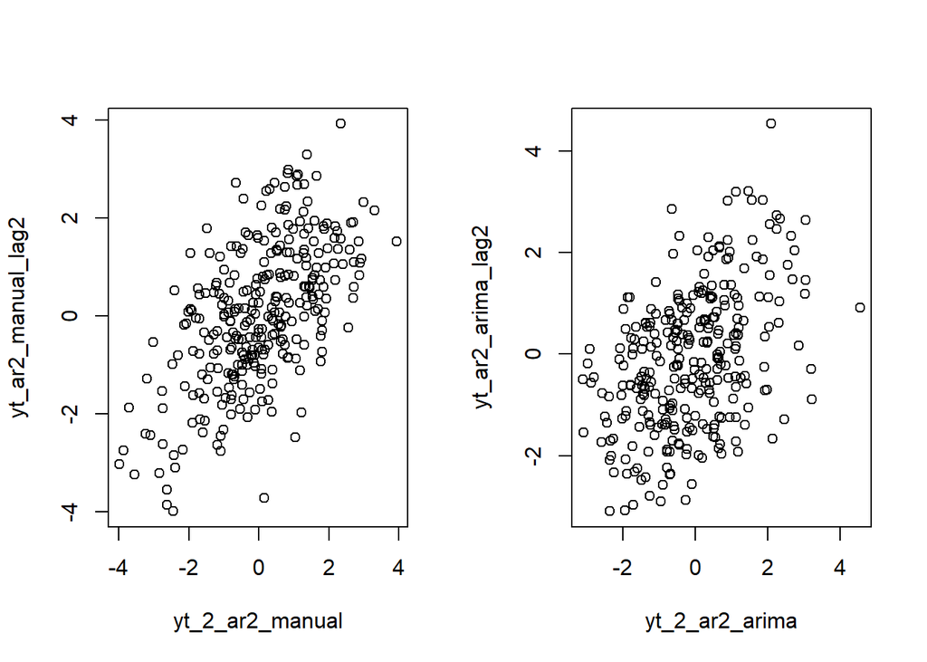

```r
plot(y=yt_ar2_arima_lag2,x=yt_2_ar2_arima)
```

#### Korelasi

```r
cor(yt_ar2_manual_lag2,yt_2_ar2_manual)
```

```
## [1] 0.5889847
```

```r
cor(yt_ar2_arima_lag2,yt_2_ar2_arima)
```

```
## [1] 0.4436581
```

Korelasi antara Yt dengan Yt−2 dari hasil simulasi mendekati perhitungan teoritis yaitu

$$\rho_2 = \phi_1 \rho_{k-1} + \phi_2
\rho_{k-2} = \frac{\phi_2(1 - \phi_2) + \phi_1^2}{1 - \phi_2} =
\frac{0.2(1 - 0.2) + 0.5^2}{1 - 0.2} = 0.5125$$

### Yt dengan Yt−3

#### Plot

```r
par(mfrow = c(1, 2))
#Yt
yt_ar2_manual_lag3 <- ar2_manual[-c(1,2,3)]
yt_ar2_manual_lag3
```

```
##   [1] -2.070930324 -0.470345231 -0.143302788 -0.740460400 -0.945522614
##   [6] -1.185305386 -1.671795045 -1.550151299 -2.107821103 -2.140194706
##  [11] -1.427202757 -0.182146261 -0.486799176 -0.790838346 -1.403974425
##  [16] -1.697326562  1.286377013  0.437811414 -0.014504787 -0.360237983
##  [21]  0.276569492 -0.627483098 -1.706632561 -0.404057179 -1.567010825
##  [26] -0.879455148 -1.689078340  0.081867346 -0.772475074 -1.079304105
##  [31] -1.195405128 -2.442656854 -2.628028715 -3.982585377 -3.857891624
##  [36] -3.019756746 -2.747354238 -0.528132203 -1.882179673 -1.902080911
##  [41] -1.608099392 -2.178805954 -2.379537173 -2.732847970 -3.094317305
##  [46] -2.617556366 -2.424491601 -3.541788331 -2.837868410 -3.236181496
##  [51] -3.200626439 -2.409859042 -1.281998990  0.524846169 -0.767330137
##  [56]  1.327213794 -0.647667678  0.598197384  2.718556227  1.444157201
##  [61]  0.596156266  0.579304817  2.185968110  0.070237282  1.840139442
##  [66]  2.263681968  1.836341670  1.377800067  0.600699629  0.209385895
##  [71]  0.873119441  2.548707761  1.295579356 -0.233169716 -0.581050764
```

[output cut: 45 more lines]

```r
# Yt-3
yt_3_ar2_manual <- ar2_manual[-c(298,299, 300)]
yt_3_ar2_manual
```

```
##   [1] -1.207065749 -0.326103633  0.679976211 -2.070930324 -0.470345231
##   [6] -0.143302788 -0.740460400 -0.945522614 -1.185305386 -1.671795045
##  [11] -1.550151299 -2.107821103 -2.140194706 -1.427202757 -0.182146261
##  [16] -0.486799176 -0.790838346 -1.403974425 -1.697326562  1.286377013
##  [21]  0.437811414 -0.014504787 -0.360237983  0.276569492 -0.627483098
##  [26] -1.706632561 -0.404057179 -1.567010825 -0.879455148 -1.689078340
##  [31]  0.081867346 -0.772475074 -1.079304105 -1.195405128 -2.442656854
##  [36] -2.628028715 -3.982585377 -3.857891624 -3.019756746 -2.747354238
##  [41] -0.528132203 -1.882179673 -1.902080911 -1.608099392 -2.178805954
##  [46] -2.379537173 -2.732847970 -3.094317305 -2.617556366 -2.424491601
##  [51] -3.541788331 -2.837868410 -3.236181496 -3.200626439 -2.409859042
##  [56] -1.281998990  0.524846169 -0.767330137  1.327213794 -0.647667678
##  [61]  0.598197384  2.718556227  1.444157201  0.596156266  0.579304817
##  [66]  2.185968110  0.070237282  1.840139442  2.263681968  1.836341670
##  [71]  1.377800067  0.600699629  0.209385895  0.873119441  2.548707761
```

[output cut: 45 more lines]

```r
plot(y=yt_ar2_manual_lag3,x=yt_3_ar2_manual)

#Yt
yt_ar2_arima_lag3 <- ar2_arima[-c(1,2,3)]
yt_ar2_arima_lag3
```

```
##   [1] -1.784562216 -2.074856748 -0.603346856  0.115336517  1.979928265
##   [6]  0.519205299 -0.696176184 -1.468891852 -1.927645533 -0.617721121
##  [11] -3.073969845 -1.105255535 -1.544078453 -0.780667738 -1.441119681
##  [16] -2.237546251 -1.120567457 -2.338668243 -1.598298743 -1.702689791
##  [21] -2.250655081 -2.969989827 -1.661653202 -0.190403943  0.288746608
##  [26]  0.192231777 -0.568477298 -2.040429169 -1.485135159 -0.811636997
##  [31] -0.443239566  0.675068462  1.054017939  2.125241038 -0.883076182
##  [36] -1.671984404 -2.580559885 -2.313009738 -1.734646274 -2.008357108
##  [41] -0.008284272 -1.275232709 -1.213701396 -0.652328651 -0.555429203
##  [46]  0.665476831  0.487308486 -1.231349306 -1.620098695 -1.397786958
##  [51] -0.680197409 -0.629349571 -1.020774866 -0.975089143 -1.448311341
##  [56] -0.144248036 -0.782066972 -1.452734085 -1.920048812  0.106817503
##  [61]  0.488751193 -0.405237469  0.730079241 -0.674487846 -1.261319914
##  [66] -2.357243530 -2.798441847 -3.095940472 -0.462035605 -0.500110261
##  [71] -1.767886587  0.460671138  0.318425904  1.353262104  0.216943712
```

[output cut: 45 more lines]

```r
# Yt-3
yt_3_ar2_arima <- ar2_arima[-c(298,299, 300)]
yt_3_ar2_arima
```

```
##   [1]  1.172148447 -0.437733455 -1.926194858 -1.784562216 -2.074856748
##   [6] -0.603346856  0.115336517  1.979928265  0.519205299 -0.696176184
##  [11] -1.468891852 -1.927645533 -0.617721121 -3.073969845 -1.105255535
##  [16] -1.544078453 -0.780667738 -1.441119681 -2.237546251 -1.120567457
##  [21] -2.338668243 -1.598298743 -1.702689791 -2.250655081 -2.969989827
##  [26] -1.661653202 -0.190403943  0.288746608  0.192231777 -0.568477298
##  [31] -2.040429169 -1.485135159 -0.811636997 -0.443239566  0.675068462
##  [36]  1.054017939  2.125241038 -0.883076182 -1.671984404 -2.580559885
##  [41] -2.313009738 -1.734646274 -2.008357108 -0.008284272 -1.275232709
##  [46] -1.213701396 -0.652328651 -0.555429203  0.665476831  0.487308486
##  [51] -1.231349306 -1.620098695 -1.397786958 -0.680197409 -0.629349571
##  [56] -1.020774866 -0.975089143 -1.448311341 -0.144248036 -0.782066972
##  [61] -1.452734085 -1.920048812  0.106817503  0.488751193 -0.405237469
##  [66]  0.730079241 -0.674487846 -1.261319914 -2.357243530 -2.798441847
##  [71] -3.095940472 -0.462035605 -0.500110261 -1.767886587  0.460671138
```

[output cut: 45 more lines]

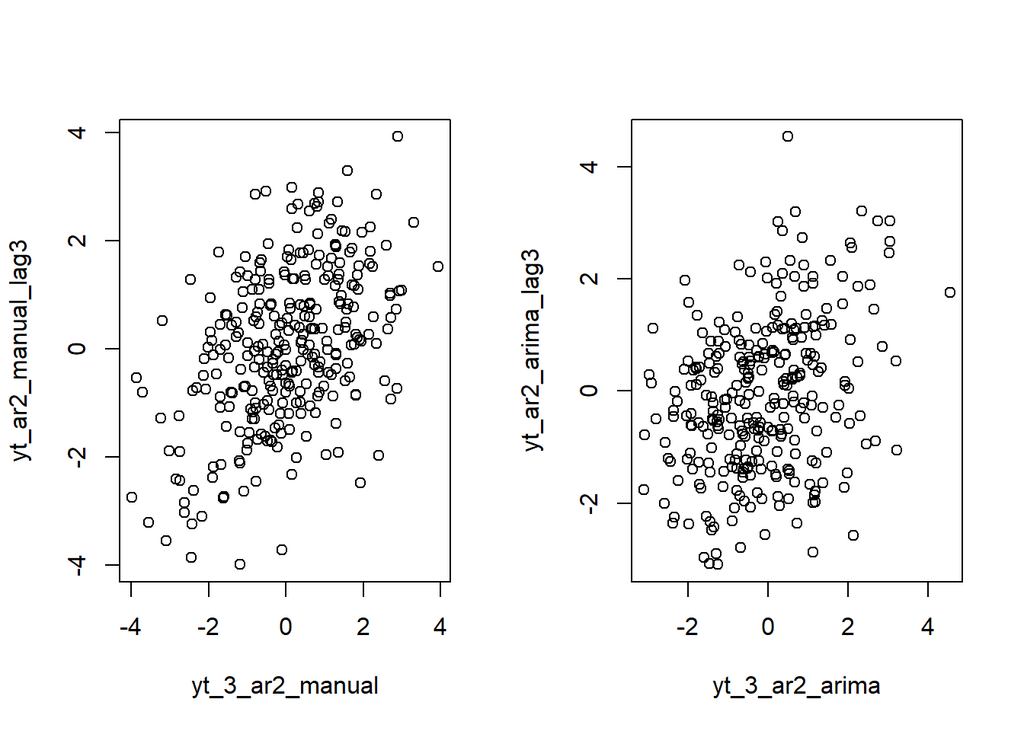

```r
plot(y=yt_ar2_arima_lag3,x=yt_3_ar2_arima)
```

Berdasarkan scatterplot tersebut, terlihat bahwa terdapat hubungan positif antara Yt dengan Yt−3. Hal ini sesuai dengan teori yang ada

#### Korelasi

```r
cor(yt_ar2_manual_lag3,yt_3_ar2_manual)
```

```
## [1] 0.4630342
```

```r
cor(yt_ar2_arima_lag3,yt_3_ar2_arima)
```

```
## [1] 0.3238443
```

Korelasi antara Yt dengan Yt−3 dari hasil simulasi mendekati perhitungan teoritis yaitu

$$\rho_3 = \phi_1 \rho_2 + \phi_2 \rho_1
= (0.5 \times 0.5125) + (0.2 \times 0.625) = 0.25625 + 0.125 = 0.38125$$

# Proses ARMA(2,2)

## Membangkitkan model ARMA(2,2)

### Manual

```r
phi1 = 0.5
phi2 = 0.2
theta1 = 0.4
theta2 = 0.6

y.arma=c(1:n)
for (i in 3:n){
  y.arma[i] = phi1*y.arma[i-1] + phi2*y.arma[i-2] +
    theta1*wn[i-1] + theta2*wn[i-2] + wn[i]
}
y.arma
```

```
##   [1]  1.00000000  2.00000000  1.67117342 -0.50987697  0.22080651 -0.72128499
##   [7] -0.43132398 -0.83281330 -1.63062016 -2.42567048 -2.71083830 -3.56383947
##  [13] -3.78601149 -3.45084825 -1.96310117 -1.35953282 -1.05181391 -1.97958403
##  [19] -2.70841035 -0.21587273 -0.05149915  0.94352638 -0.09490594  0.13021106
##  [25] -0.72808885 -1.78794156 -1.46034694 -2.75043816 -1.74703563 -2.97980280
##  [31] -1.12047340 -1.75244048 -1.33861366 -2.09018485 -3.56807587 -4.32208639
##  [37] -6.49920181 -7.02759879 -6.95235468 -6.26990810 -3.43886405 -3.74179639
##  [43] -2.97179497 -3.49821125 -3.96327268 -4.21590274 -4.99193387 -5.61516924
##  [49] -5.49498478 -5.32809897 -6.08211455 -5.70927547 -6.49639940 -6.19781821
##  [55] -5.63181708 -4.16631738 -1.43386802 -1.32659043  1.33518992 -0.57717987
##  [61]  1.13545887  2.56923479  2.89049829  2.80495301  1.68426174  2.77538387
##  [67]  1.29220747  3.17981526  3.04188015  3.84589815  3.47054593  2.25362467
##  [73]  1.27634580  1.31729358  3.02358708  2.83893413  1.81428669  0.10302897
##  [79] -0.45121970 -0.85290753 -0.66635425 -0.93510416 -2.14779642 -2.08562341
##  [85] -1.51503473 -0.24121274  0.91556687  0.64537308  0.48311177 -1.14217407
```

[output cut: 35 more lines]

### arima.sim

```r
arma22 <- arima.sim(list(order=c(2,0,2), ar = c(0.5,0.2), ma = c(0.4,0.6)), n=300)
arma22
```

```
## Time Series:
## Start = 1
## End = 300
## Frequency = 1
##   [1]  1.99672450  0.50022694 -1.36027652 -3.08346416 -2.73757924 -3.40811247
##   [7] -2.96022156 -1.28575528  1.93343236  2.45248957  4.13284826  2.64419753
##  [13]  3.99266224  2.02264256  1.67674152 -0.15597163  0.59311857 -1.07092032
##  [19]  0.53947108 -0.34927011 -0.14923335  0.81983669  1.43188003  0.70916026
##  [25]  0.02253246  0.28484319  0.35336987  1.43244964  0.94333883 -0.06337770
##  [31] -0.04371294 -1.65435134 -0.18245926 -0.45203704 -0.31947470 -2.22618972
##  [37] -0.83678946 -2.35386843 -0.51198413  0.11383002  0.13620004  1.02031966
##  [43]  0.06170341  0.83237124 -0.65575308  0.31579383 -0.44621130 -0.08262191
##  [49] -0.60090009 -0.66610380 -1.14519462 -0.27722557 -0.94386653 -1.78365745
##  [55] -0.20609521  1.10663125  1.67103111  1.14867008  0.80597227 -0.78263044
##  [61]  0.41509877 -0.54452787 -0.50314966 -0.74623057 -0.55115213 -0.34038902
```

[output cut: 39 more lines]

## Karakteristik ARMA (2,2)

### Plot Time Series

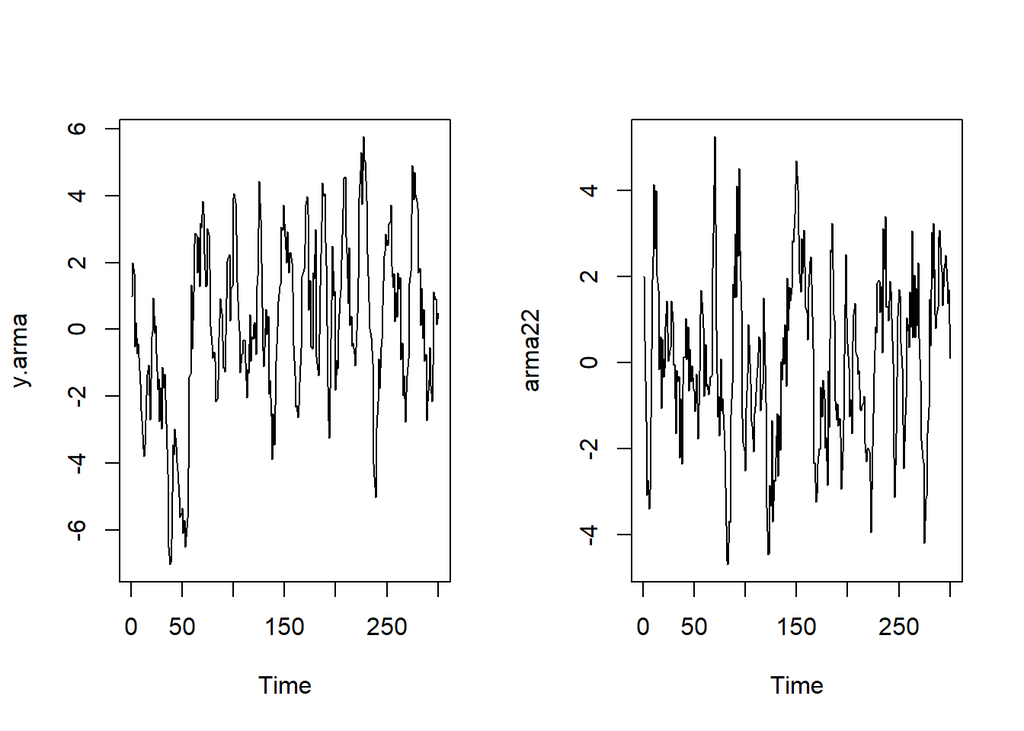

```r
par(mfrow = c(1, 2))
ts.plot(y.arma)
ts.plot(arma22)
```

Berdasarkan plot time series tersebut, terlihat bahwa model ARMA(2,2) stasioner dalam rataan.

### Plot ACF

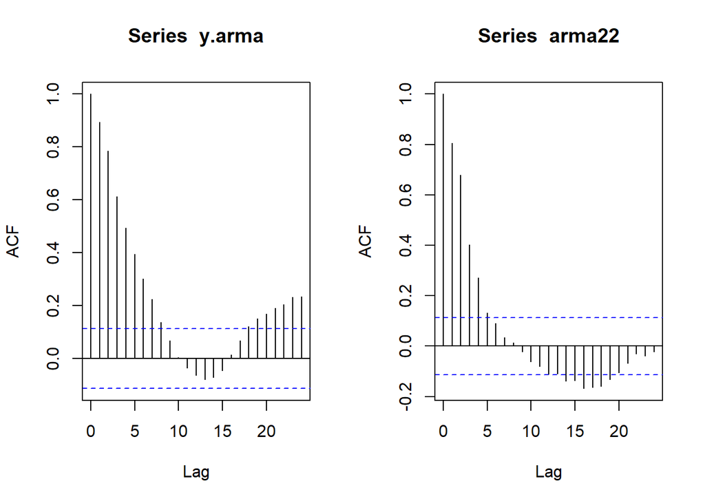

```r
par(mfrow = c(1, 2))
acf(y.arma)
acf(arma22)
```

```r
par(mfrow = c(1, 1))
```

Berdasarkan plot ACF tersebut, terlihat bahwa model ARMA(2,2) hasil simulasi memiliki plot ACF yang *tails off*, sesuai dengan teori yang ada

### Plot PACF

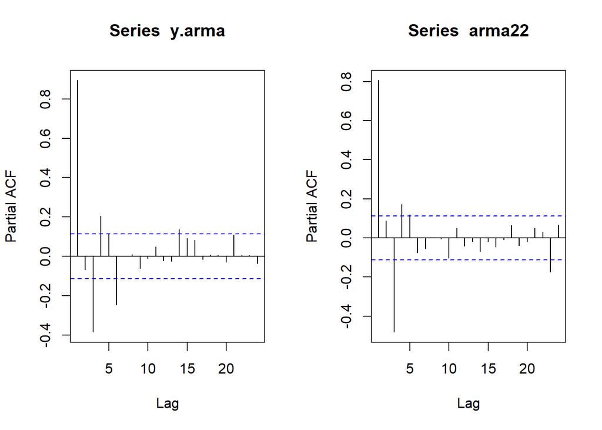

```r
par(mfrow = c(1, 2))
pacf(y.arma)
pacf(arma22)
```

```r
par(mfrow = c(1, 1))
```

Berdasarkan plot PACF tersebut, terlihat bahwa model ARMA(2,2) baik hasil simulasi maupun dengan pembangkitan fungsi memiliki plot PACF yang *tails off*

### Plot EACF

```r
TSA::eacf(y.arma)
```

```
## AR/MA
##   0 1 2 3 4 5 6 7 8 9 10 11 12 13
## 0 x x x x x x x x o o o  o  o  o
## 1 o x o o o o x o o o o  o  o  o
## 2 x x o o o o x o o o o  o  o  o
## 3 x x o x o o x o o o o  o  o  o
## 4 x x x x o o x o o o o  o  o  o
## 5 x x x x x x x o o o o  o  o  o
## 6 o o x o x x o o o o o  o  o  o
## 7 x o x o x x o x o o o  o  o  o
```

```r
TSA::eacf(arma22)
```

```
## AR/MA
##   0 1 2 3 4 5 6 7 8 9 10 11 12 13
## 0 x x x x x o o o o o o  o  o  x
## 1 o x x x x o o o o o o  o  o  o
## 2 x x x o o o o o o o o  o  o  o
## 3 x x o o o o o o o o o  o  o  o
## 4 x x x o o o o o o o o  o  o  o
## 5 x x x o o o o o o o o  o  o  o
## 6 x x o o o o x o o o o  o  o  o
## 7 x x o o x x x x o o o  o  o  o
```

### Kesimpulan

Berdasarkan plot time series, ACF, dan PACF, model ARMA(2,2) hasil simulasi menunjukkan karakteristik yang mengindikasikan stasioneritas. Plot time series berfluktuasi di sekitar rataan yang relatif konstan, sedangkan ACF dan PACF menunjukkan pola tails off yang menurun menuju nol. Dengan demikian, model ARMA(2,2) hasil simulasi dapat dikatakan stasioner.

## Scatterplot & Auto korelasi Antar Lag

### Yt dengan Yt−1

#### Plot

```r
par(mfrow = c(1, 2))
#Yt
yt_arma_manual <- y.arma[-1]
yt_arma_manual
```

```
##   [1]  2.00000000  1.67117342 -0.50987697  0.22080651 -0.72128499 -0.43132398
##   [7] -0.83281330 -1.63062016 -2.42567048 -2.71083830 -3.56383947 -3.78601149
##  [13] -3.45084825 -1.96310117 -1.35953282 -1.05181391 -1.97958403 -2.70841035
##  [19] -0.21587273 -0.05149915  0.94352638 -0.09490594  0.13021106 -0.72808885
##  [25] -1.78794156 -1.46034694 -2.75043816 -1.74703563 -2.97980280 -1.12047340
##  [31] -1.75244048 -1.33861366 -2.09018485 -3.56807587 -4.32208639 -6.49920181
##  [37] -7.02759879 -6.95235468 -6.26990810 -3.43886405 -3.74179639 -2.97179497
##  [43] -3.49821125 -3.96327268 -4.21590274 -4.99193387 -5.61516924 -5.49498478
##  [49] -5.32809897 -6.08211455 -5.70927547 -6.49639940 -6.19781821 -5.63181708
##  [55] -4.16631738 -1.43386802 -1.32659043  1.33518992 -0.57717987  1.13545887
##  [61]  2.56923479  2.89049829  2.80495301  1.68426174  2.77538387  1.29220747
##  [67]  3.17981526  3.04188015  3.84589815  3.47054593  2.25362467  1.27634580
##  [73]  1.31729358  3.02358708  2.83893413  1.81428669  0.10302897 -0.45121970
##  [79] -0.85290753 -0.66635425 -0.93510416 -2.14779642 -2.08562341 -1.51503473
##  [85] -0.24121274  0.91556687  0.64537308  0.48311177 -1.14217407 -1.12039092
```

[output cut: 35 more lines]

```r
#Yt-1
yt_1_arma_manual <- y.arma[-300]
yt_1_arma_manual
```

```
##   [1]  1.00000000  2.00000000  1.67117342 -0.50987697  0.22080651 -0.72128499
##   [7] -0.43132398 -0.83281330 -1.63062016 -2.42567048 -2.71083830 -3.56383947
##  [13] -3.78601149 -3.45084825 -1.96310117 -1.35953282 -1.05181391 -1.97958403
##  [19] -2.70841035 -0.21587273 -0.05149915  0.94352638 -0.09490594  0.13021106
##  [25] -0.72808885 -1.78794156 -1.46034694 -2.75043816 -1.74703563 -2.97980280
##  [31] -1.12047340 -1.75244048 -1.33861366 -2.09018485 -3.56807587 -4.32208639
##  [37] -6.49920181 -7.02759879 -6.95235468 -6.26990810 -3.43886405 -3.74179639
##  [43] -2.97179497 -3.49821125 -3.96327268 -4.21590274 -4.99193387 -5.61516924
##  [49] -5.49498478 -5.32809897 -6.08211455 -5.70927547 -6.49639940 -6.19781821
##  [55] -5.63181708 -4.16631738 -1.43386802 -1.32659043  1.33518992 -0.57717987
##  [61]  1.13545887  2.56923479  2.89049829  2.80495301  1.68426174  2.77538387
##  [67]  1.29220747  3.17981526  3.04188015  3.84589815  3.47054593  2.25362467
##  [73]  1.27634580  1.31729358  3.02358708  2.83893413  1.81428669  0.10302897
##  [79] -0.45121970 -0.85290753 -0.66635425 -0.93510416 -2.14779642 -2.08562341
##  [85] -1.51503473 -0.24121274  0.91556687  0.64537308  0.48311177 -1.14217407
```

[output cut: 35 more lines]

```r
plot(y=yt_arma_manual,x=yt_1_arma_manual)

#Yt
yt_arma_arima <- arma22[-1]
yt_arma_arima
```

```
##   [1]  0.50022694 -1.36027652 -3.08346416 -2.73757924 -3.40811247 -2.96022156
##   [7] -1.28575528  1.93343236  2.45248957  4.13284826  2.64419753  3.99266224
##  [13]  2.02264256  1.67674152 -0.15597163  0.59311857 -1.07092032  0.53947108
##  [19] -0.34927011 -0.14923335  0.81983669  1.43188003  0.70916026  0.02253246
##  [25]  0.28484319  0.35336987  1.43244964  0.94333883 -0.06337770 -0.04371294
##  [31] -1.65435134 -0.18245926 -0.45203704 -0.31947470 -2.22618972 -0.83678946
##  [37] -2.35386843 -0.51198413  0.11383002  0.13620004  1.02031966  0.06170341
##  [43]  0.83237124 -0.65575308  0.31579383 -0.44621130 -0.08262191 -0.60090009
##  [49] -0.66610380 -1.14519462 -0.27722557 -0.94386653 -1.78365745 -0.20609521
##  [55]  1.10663125  1.67103111  1.14867008  0.80597227 -0.78263044  0.41509877
##  [61] -0.54452787 -0.50314966 -0.74623057 -0.55115213 -0.34038902 -0.31220880
##  [67]  2.19437851  2.99688424  5.24667108  3.21280416  0.75207083 -1.27004571
##  [73] -0.78945851 -1.70978766  0.08481854 -1.12773524 -0.84170004 -1.56349281
##  [79] -2.04840215 -3.79485390 -4.61148327 -4.69947486 -3.68922433 -3.71954425
##  [85] -1.22011775 -0.48887187  1.81243737  1.49177495  2.99316736  1.52019016
```

[output cut: 35 more lines]

```r
#Yt-1
yt_1_arma_arima <- arma22[-300]
yt_1_arma_arima
```

```
##   [1]  1.99672450  0.50022694 -1.36027652 -3.08346416 -2.73757924 -3.40811247
##   [7] -2.96022156 -1.28575528  1.93343236  2.45248957  4.13284826  2.64419753
##  [13]  3.99266224  2.02264256  1.67674152 -0.15597163  0.59311857 -1.07092032
##  [19]  0.53947108 -0.34927011 -0.14923335  0.81983669  1.43188003  0.70916026
##  [25]  0.02253246  0.28484319  0.35336987  1.43244964  0.94333883 -0.06337770
##  [31] -0.04371294 -1.65435134 -0.18245926 -0.45203704 -0.31947470 -2.22618972
##  [37] -0.83678946 -2.35386843 -0.51198413  0.11383002  0.13620004  1.02031966
##  [43]  0.06170341  0.83237124 -0.65575308  0.31579383 -0.44621130 -0.08262191
##  [49] -0.60090009 -0.66610380 -1.14519462 -0.27722557 -0.94386653 -1.78365745
##  [55] -0.20609521  1.10663125  1.67103111  1.14867008  0.80597227 -0.78263044
##  [61]  0.41509877 -0.54452787 -0.50314966 -0.74623057 -0.55115213 -0.34038902
##  [67] -0.31220880  2.19437851  2.99688424  5.24667108  3.21280416  0.75207083
##  [73] -1.27004571 -0.78945851 -1.70978766  0.08481854 -1.12773524 -0.84170004
##  [79] -1.56349281 -2.04840215 -3.79485390 -4.61148327 -4.69947486 -3.68922433
##  [85] -3.71954425 -1.22011775 -0.48887187  1.81243737  1.49177495  2.99316736
```

[output cut: 35 more lines]

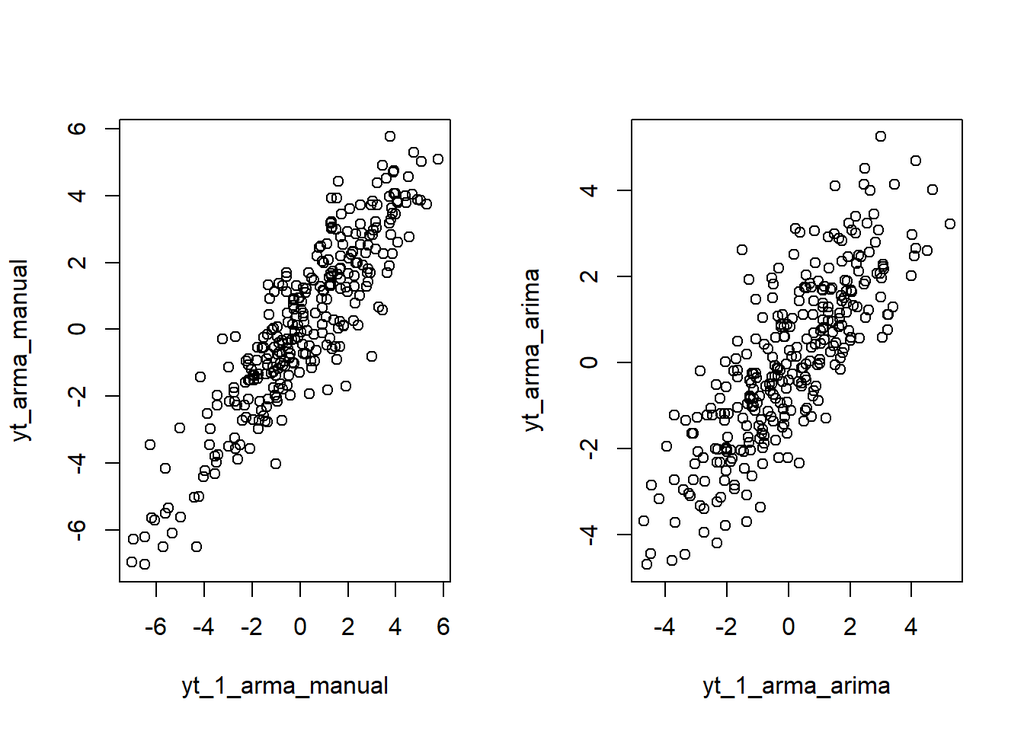

```r
plot(y=yt_arma_arima,x=yt_1_arma_arima)
```

Berdasarkan scatterplot tersebut, terlihat bahwa terdapat hubungan positif antara Yt dengan Yt−1. Hal ini sesuai dengan teori yang ada

#### Korelasi

```r
cor(yt_arma_manual,yt_1_arma_manual)
```

```
## [1] 0.8943281
```

```r
cor(yt_arma_arima,yt_1_arma_arima)
```

```
## [1] 0.8069214
```

Korelasi antara Yt dengan Yt−1 dari hasil simulasi mendekati perhitungan teoritis yaitu

```r
# ACF teoritis ARMA(2,2) lag 1
rho.arma.teori <- ARMAacf(
  ar = c(0.5, 0.2),
  ma = c(0.4, 0.6),
  lag.max = 1
)

acf_teori_lag1 <- rho.arma.teori[2]
acf_teori_lag1
```

```
##         1
## 0.8591993
```

### Yt dengan Yt−2

#### Plot

```r
par(mfrow = c(1, 2))
#Yt
yt_arma_manual_lag2 <- y.arma[-c(1,2)]
yt_arma_manual_lag2
```

```
##   [1]  1.67117342 -0.50987697  0.22080651 -0.72128499 -0.43132398 -0.83281330
##   [7] -1.63062016 -2.42567048 -2.71083830 -3.56383947 -3.78601149 -3.45084825
##  [13] -1.96310117 -1.35953282 -1.05181391 -1.97958403 -2.70841035 -0.21587273
##  [19] -0.05149915  0.94352638 -0.09490594  0.13021106 -0.72808885 -1.78794156
##  [25] -1.46034694 -2.75043816 -1.74703563 -2.97980280 -1.12047340 -1.75244048
##  [31] -1.33861366 -2.09018485 -3.56807587 -4.32208639 -6.49920181 -7.02759879
##  [37] -6.95235468 -6.26990810 -3.43886405 -3.74179639 -2.97179497 -3.49821125
##  [43] -3.96327268 -4.21590274 -4.99193387 -5.61516924 -5.49498478 -5.32809897
##  [49] -6.08211455 -5.70927547 -6.49639940 -6.19781821 -5.63181708 -4.16631738
##  [55] -1.43386802 -1.32659043  1.33518992 -0.57717987  1.13545887  2.56923479
##  [61]  2.89049829  2.80495301  1.68426174  2.77538387  1.29220747  3.17981526
##  [67]  3.04188015  3.84589815  3.47054593  2.25362467  1.27634580  1.31729358
##  [73]  3.02358708  2.83893413  1.81428669  0.10302897 -0.45121970 -0.85290753
##  [79] -0.66635425 -0.93510416 -2.14779642 -2.08562341 -1.51503473 -0.24121274
##  [85]  0.91556687  0.64537308  0.48311177 -1.14217407 -1.12039092 -1.27141453
```

[output cut: 35 more lines]

```r
#Yt-2
yt_2_arma_manual <- y.arma[-c(299,300)]
yt_2_arma_manual
```

```
##   [1]  1.00000000  2.00000000  1.67117342 -0.50987697  0.22080651 -0.72128499
##   [7] -0.43132398 -0.83281330 -1.63062016 -2.42567048 -2.71083830 -3.56383947
##  [13] -3.78601149 -3.45084825 -1.96310117 -1.35953282 -1.05181391 -1.97958403
##  [19] -2.70841035 -0.21587273 -0.05149915  0.94352638 -0.09490594  0.13021106
##  [25] -0.72808885 -1.78794156 -1.46034694 -2.75043816 -1.74703563 -2.97980280
##  [31] -1.12047340 -1.75244048 -1.33861366 -2.09018485 -3.56807587 -4.32208639
##  [37] -6.49920181 -7.02759879 -6.95235468 -6.26990810 -3.43886405 -3.74179639
##  [43] -2.97179497 -3.49821125 -3.96327268 -4.21590274 -4.99193387 -5.61516924
##  [49] -5.49498478 -5.32809897 -6.08211455 -5.70927547 -6.49639940 -6.19781821
##  [55] -5.63181708 -4.16631738 -1.43386802 -1.32659043  1.33518992 -0.57717987
##  [61]  1.13545887  2.56923479  2.89049829  2.80495301  1.68426174  2.77538387
##  [67]  1.29220747  3.17981526  3.04188015  3.84589815  3.47054593  2.25362467
##  [73]  1.27634580  1.31729358  3.02358708  2.83893413  1.81428669  0.10302897
##  [79] -0.45121970 -0.85290753 -0.66635425 -0.93510416 -2.14779642 -2.08562341
##  [85] -1.51503473 -0.24121274  0.91556687  0.64537308  0.48311177 -1.14217407
```

[output cut: 35 more lines]

```r
plot(y=yt_arma_manual_lag2,x=yt_2_arma_manual)

#Yt
yt_arma_arima_lag2 <- arma22[-c(1,2)]
yt_arma_arima_lag2
```

```
##   [1] -1.36027652 -3.08346416 -2.73757924 -3.40811247 -2.96022156 -1.28575528
##   [7]  1.93343236  2.45248957  4.13284826  2.64419753  3.99266224  2.02264256
##  [13]  1.67674152 -0.15597163  0.59311857 -1.07092032  0.53947108 -0.34927011
##  [19] -0.14923335  0.81983669  1.43188003  0.70916026  0.02253246  0.28484319
##  [25]  0.35336987  1.43244964  0.94333883 -0.06337770 -0.04371294 -1.65435134
##  [31] -0.18245926 -0.45203704 -0.31947470 -2.22618972 -0.83678946 -2.35386843
##  [37] -0.51198413  0.11383002  0.13620004  1.02031966  0.06170341  0.83237124
##  [43] -0.65575308  0.31579383 -0.44621130 -0.08262191 -0.60090009 -0.66610380
##  [49] -1.14519462 -0.27722557 -0.94386653 -1.78365745 -0.20609521  1.10663125
##  [55]  1.67103111  1.14867008  0.80597227 -0.78263044  0.41509877 -0.54452787
##  [61] -0.50314966 -0.74623057 -0.55115213 -0.34038902 -0.31220880  2.19437851
##  [67]  2.99688424  5.24667108  3.21280416  0.75207083 -1.27004571 -0.78945851
##  [73] -1.70978766  0.08481854 -1.12773524 -0.84170004 -1.56349281 -2.04840215
##  [79] -3.79485390 -4.61148327 -4.69947486 -3.68922433 -3.71954425 -1.22011775
##  [85] -0.48887187  1.81243737  1.49177495  2.99316736  1.52019016  4.09766192
```

[output cut: 35 more lines]

```r
#Yt-2
yt_2_arma_arima <- arma22[-c(299,300)]
yt_2_arma_arima
```

```
##   [1]  1.99672450  0.50022694 -1.36027652 -3.08346416 -2.73757924 -3.40811247
##   [7] -2.96022156 -1.28575528  1.93343236  2.45248957  4.13284826  2.64419753
##  [13]  3.99266224  2.02264256  1.67674152 -0.15597163  0.59311857 -1.07092032
##  [19]  0.53947108 -0.34927011 -0.14923335  0.81983669  1.43188003  0.70916026
##  [25]  0.02253246  0.28484319  0.35336987  1.43244964  0.94333883 -0.06337770
##  [31] -0.04371294 -1.65435134 -0.18245926 -0.45203704 -0.31947470 -2.22618972
##  [37] -0.83678946 -2.35386843 -0.51198413  0.11383002  0.13620004  1.02031966
##  [43]  0.06170341  0.83237124 -0.65575308  0.31579383 -0.44621130 -0.08262191
##  [49] -0.60090009 -0.66610380 -1.14519462 -0.27722557 -0.94386653 -1.78365745
##  [55] -0.20609521  1.10663125  1.67103111  1.14867008  0.80597227 -0.78263044
##  [61]  0.41509877 -0.54452787 -0.50314966 -0.74623057 -0.55115213 -0.34038902
##  [67] -0.31220880  2.19437851  2.99688424  5.24667108  3.21280416  0.75207083
##  [73] -1.27004571 -0.78945851 -1.70978766  0.08481854 -1.12773524 -0.84170004
##  [79] -1.56349281 -2.04840215 -3.79485390 -4.61148327 -4.69947486 -3.68922433
##  [85] -3.71954425 -1.22011775 -0.48887187  1.81243737  1.49177495  2.99316736
```

[output cut: 35 more lines]

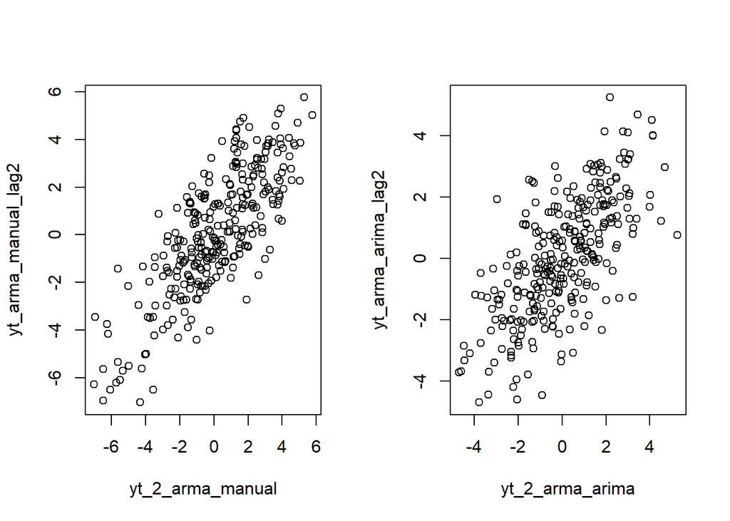

```r
plot(y=yt_arma_arima_lag2,x=yt_2_arma_arima)
```

#### Korelasi

```r
cor(yt_arma_manual_lag2, yt_2_arma_manual)
```

```
## [1] 0.7865019
```

```r
cor(yt_arma_arima_lag2, yt_2_arma_arima)
```

```
## [1] 0.6817002
```

Korelasi antara Yt dengan Yt−2 dari hasil simulasi mendekati perhitungan teoritis yaitu

```r
# ACF teoritis ARMA(2,2) lag 2
rho.arma.teori <- ARMAacf(
  ar = c(0.5, 0.2),
  ma = c(0.4, 0.6),
  lag.max = 2
)

acf_teori_lag2 <- rho.arma.teori[3]
acf_teori_lag2
```

```
##         2
## 0.7491908
```

### Yt dengan Yt−3

#### Plot

```r
#Yt
yt_arma_manual_lag3 <- y.arma[-c(1,2,3)]
yt_arma_manual_lag3
```

```
##   [1] -0.50987697  0.22080651 -0.72128499 -0.43132398 -0.83281330 -1.63062016
##   [7] -2.42567048 -2.71083830 -3.56383947 -3.78601149 -3.45084825 -1.96310117
##  [13] -1.35953282 -1.05181391 -1.97958403 -2.70841035 -0.21587273 -0.05149915
##  [19]  0.94352638 -0.09490594  0.13021106 -0.72808885 -1.78794156 -1.46034694
##  [25] -2.75043816 -1.74703563 -2.97980280 -1.12047340 -1.75244048 -1.33861366
##  [31] -2.09018485 -3.56807587 -4.32208639 -6.49920181 -7.02759879 -6.95235468
##  [37] -6.26990810 -3.43886405 -3.74179639 -2.97179497 -3.49821125 -3.96327268
##  [43] -4.21590274 -4.99193387 -5.61516924 -5.49498478 -5.32809897 -6.08211455
##  [49] -5.70927547 -6.49639940 -6.19781821 -5.63181708 -4.16631738 -1.43386802
##  [55] -1.32659043  1.33518992 -0.57717987  1.13545887  2.56923479  2.89049829
##  [61]  2.80495301  1.68426174  2.77538387  1.29220747  3.17981526  3.04188015
##  [67]  3.84589815  3.47054593  2.25362467  1.27634580  1.31729358  3.02358708
##  [73]  2.83893413  1.81428669  0.10302897 -0.45121970 -0.85290753 -0.66635425
##  [79] -0.93510416 -2.14779642 -2.08562341 -1.51503473 -0.24121274  0.91556687
##  [85]  0.64537308  0.48311177 -1.14217407 -1.12039092 -1.27141453  0.91636167
```

[output cut: 35 more lines]

```r
# Yt-3
yt_3_arma_manual <- y.arma[-c(298,299, 300)]
yt_3_arma_manual
```

```
##   [1]  1.00000000  2.00000000  1.67117342 -0.50987697  0.22080651 -0.72128499
##   [7] -0.43132398 -0.83281330 -1.63062016 -2.42567048 -2.71083830 -3.56383947
##  [13] -3.78601149 -3.45084825 -1.96310117 -1.35953282 -1.05181391 -1.97958403
##  [19] -2.70841035 -0.21587273 -0.05149915  0.94352638 -0.09490594  0.13021106
##  [25] -0.72808885 -1.78794156 -1.46034694 -2.75043816 -1.74703563 -2.97980280
##  [31] -1.12047340 -1.75244048 -1.33861366 -2.09018485 -3.56807587 -4.32208639
##  [37] -6.49920181 -7.02759879 -6.95235468 -6.26990810 -3.43886405 -3.74179639
##  [43] -2.97179497 -3.49821125 -3.96327268 -4.21590274 -4.99193387 -5.61516924
##  [49] -5.49498478 -5.32809897 -6.08211455 -5.70927547 -6.49639940 -6.19781821
##  [55] -5.63181708 -4.16631738 -1.43386802 -1.32659043  1.33518992 -0.57717987
##  [61]  1.13545887  2.56923479  2.89049829  2.80495301  1.68426174  2.77538387
##  [67]  1.29220747  3.17981526  3.04188015  3.84589815  3.47054593  2.25362467
##  [73]  1.27634580  1.31729358  3.02358708  2.83893413  1.81428669  0.10302897
##  [79] -0.45121970 -0.85290753 -0.66635425 -0.93510416 -2.14779642 -2.08562341
##  [85] -1.51503473 -0.24121274  0.91556687  0.64537308  0.48311177 -1.14217407
```

[output cut: 35 more lines]

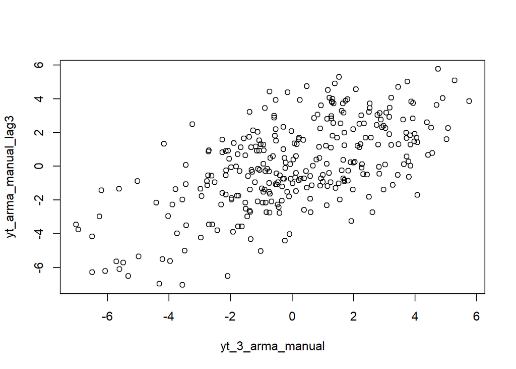

```r
plot(y=yt_arma_manual_lag3,x=yt_3_arma_manual)
```

```r
#Yt
yt_arma_arima_lag3 <- arma22[-c(1,2,3)]
yt_arma_manual_lag3
```

```
##   [1] -0.50987697  0.22080651 -0.72128499 -0.43132398 -0.83281330 -1.63062016
##   [7] -2.42567048 -2.71083830 -3.56383947 -3.78601149 -3.45084825 -1.96310117
##  [13] -1.35953282 -1.05181391 -1.97958403 -2.70841035 -0.21587273 -0.05149915
##  [19]  0.94352638 -0.09490594  0.13021106 -0.72808885 -1.78794156 -1.46034694
##  [25] -2.75043816 -1.74703563 -2.97980280 -1.12047340 -1.75244048 -1.33861366
##  [31] -2.09018485 -3.56807587 -4.32208639 -6.49920181 -7.02759879 -6.95235468
##  [37] -6.26990810 -3.43886405 -3.74179639 -2.97179497 -3.49821125 -3.96327268
##  [43] -4.21590274 -4.99193387 -5.61516924 -5.49498478 -5.32809897 -6.08211455
##  [49] -5.70927547 -6.49639940 -6.19781821 -5.63181708 -4.16631738 -1.43386802
##  [55] -1.32659043  1.33518992 -0.57717987  1.13545887  2.56923479  2.89049829
##  [61]  2.80495301  1.68426174  2.77538387  1.29220747  3.17981526  3.04188015
##  [67]  3.84589815  3.47054593  2.25362467  1.27634580  1.31729358  3.02358708
##  [73]  2.83893413  1.81428669  0.10302897 -0.45121970 -0.85290753 -0.66635425
##  [79] -0.93510416 -2.14779642 -2.08562341 -1.51503473 -0.24121274  0.91556687
##  [85]  0.64537308  0.48311177 -1.14217407 -1.12039092 -1.27141453  0.91636167
```

[output cut: 35 more lines]

```r
# Yt-3
yt_3_arma_arima <- arma22[-c(298,299, 300)]
yt_3_arma_arima
```

```
##   [1]  1.99672450  0.50022694 -1.36027652 -3.08346416 -2.73757924 -3.40811247
##   [7] -2.96022156 -1.28575528  1.93343236  2.45248957  4.13284826  2.64419753
##  [13]  3.99266224  2.02264256  1.67674152 -0.15597163  0.59311857 -1.07092032
##  [19]  0.53947108 -0.34927011 -0.14923335  0.81983669  1.43188003  0.70916026
##  [25]  0.02253246  0.28484319  0.35336987  1.43244964  0.94333883 -0.06337770
##  [31] -0.04371294 -1.65435134 -0.18245926 -0.45203704 -0.31947470 -2.22618972
##  [37] -0.83678946 -2.35386843 -0.51198413  0.11383002  0.13620004  1.02031966
##  [43]  0.06170341  0.83237124 -0.65575308  0.31579383 -0.44621130 -0.08262191
##  [49] -0.60090009 -0.66610380 -1.14519462 -0.27722557 -0.94386653 -1.78365745
##  [55] -0.20609521  1.10663125  1.67103111  1.14867008  0.80597227 -0.78263044
##  [61]  0.41509877 -0.54452787 -0.50314966 -0.74623057 -0.55115213 -0.34038902
##  [67] -0.31220880  2.19437851  2.99688424  5.24667108  3.21280416  0.75207083
##  [73] -1.27004571 -0.78945851 -1.70978766  0.08481854 -1.12773524 -0.84170004
##  [79] -1.56349281 -2.04840215 -3.79485390 -4.61148327 -4.69947486 -3.68922433
##  [85] -3.71954425 -1.22011775 -0.48887187  1.81243737  1.49177495  2.99316736
```

[output cut: 35 more lines]

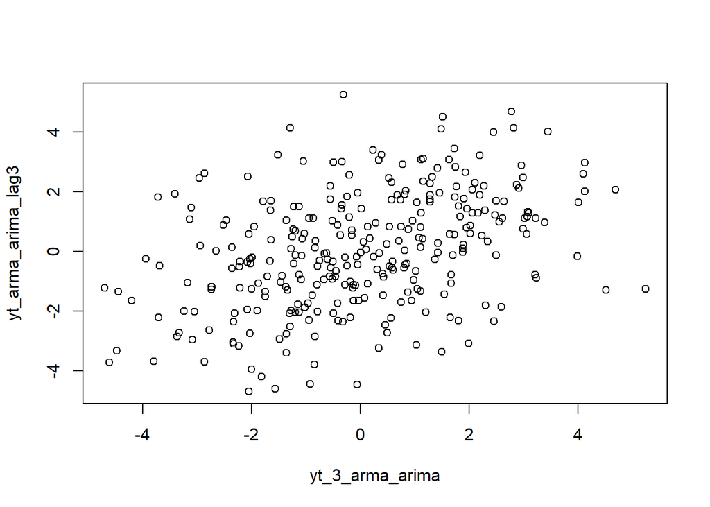

```r
plot(y=yt_arma_arima_lag3,x=yt_3_arma_arima)
```

Berdasarkan scatterplot tersebut, terlihat bahwa terdapat hubungan positif antara Yt dengan Yt−3. Hal ini sesuai dengan teori yang ada

#### Korelasi

```r
cor(yt_arma_manual_lag3, yt_3_arma_manual)
```

```
## [1] 0.6135111
```

```r
cor(yt_arma_arima_lag3, yt_3_arma_arima)
```

```
## [1] 0.4042615
```

Korelasi antara Yt dengan Yt−3 dari hasil simulasi mendekati perhitungan teoritis yaitu

```r
# ACF teoritis ARMA(2,2) lag 3
rho.arma.teori <- ARMAacf(
  ar = c(0.5, 0.2),
  ma = c(0.4, 0.6),
  lag.max = 3
)

acf_teori_lag3 <- rho.arma.teori[4]
acf_teori_lag3
```

```
##         3
## 0.5464353
```

# Tugas-Pertemuan-4

**Nur Annisa Hartanti Putri - M0401241051**

# White Noise

```r
set.seed(1234)
wn <- rnorm(300)
```

# Proses MA(2)

Dalam kasus ini, akan dibangkitkan suatu data dengan model MA(2) sebanyak 300 data yang memiliki nilai θ1=0.4 dan θ2=0.6. Rumusan model tersebut adalah sebagai berikut

$$Y_t = c + e_t + \theta_1 e_{t-1} + \theta_2 e_{t-2}$$

$$Y_t = e_t + 0.4e_{t-1} + 0.6e_{t-2}$$

## Membangkitkan Model MA(2)

### Manual

```r
ma2_manual <- c(wn[1], wn[2] + 0.4 * wn[1])

for(i in 3:300){
  ma2_manual[i] <- wn[i] + 0.4 * wn[i - 1] + 0.6 * wn[i - 2]
}

ma2_manual
```

```
##   [1] -1.207065749 -0.205397058  0.471173424 -1.745463687  0.141510314
##   [6] -0.729712854 -0.114842790 -0.472894305 -1.127948717 -1.443797742
##  [11] -1.171879031 -1.723286222 -1.461924092 -0.845074607  0.519525249
##  [16]  0.312187420  0.020572732 -1.181770516 -1.508255550  1.534249256
##  [21]  0.598119283  1.012450498 -0.556369299 -0.011041246 -0.774213194
##  [26] -1.449939345 -0.420758391 -1.662676381 -0.079747157 -1.556197355
##  [31]  0.718835126 -0.596243221 -0.238298741 -1.070389923 -2.255260716
##  [36] -2.120011486 -3.624543435 -2.913580609 -2.138714925 -1.388210999
##  [41]  1.086560934 -0.768382742 -0.413123964 -1.263954490 -1.619808057
##  [46] -1.534624150 -2.091327966 -2.276021753 -1.689013389 -1.457572736
##  [51] -2.319068111 -1.602598402 -2.425338748 -1.807763414 -1.233628102
##  [56] -0.110845196  1.775654086  0.223607057  2.285258743 -0.979456751
##  [61]  1.157010823  2.116941328  1.378789117  0.845856907 -0.296314421
##  [66]  1.372262398 -0.432336811  1.978634754  1.193531021  1.688995021
##  [71]  0.939220832 -0.250827924 -0.544575725  0.228395751  2.109671129
```

[output cut: 45 more lines]

### arima.sim

```r
ma2_arima <- arima.sim(list(order=c(0,0,2), ma=c(0.4, 0.6)), n=300)
ma2_arima
```

```
## Time Series:
## Start = 1
## End = 300
## Frequency = 1
##   [1] -0.908714261  0.366069559  0.319892749 -0.033692645 -0.749809541
##   [6]  1.023224875 -0.103827746  1.553027734  1.508813504  1.490258435
##  [11]  0.638775303  0.057508568 -0.761313741  1.006804154  0.046165301
##  [16]  2.226792228 -0.031351321  0.058227766 -0.452682262 -0.306828839
##  [21] -0.408896770 -1.768664231 -0.905163217 -1.653388217  0.814020129
##  [26] -0.949587092  1.394975120 -0.770061199  0.708742509  0.626264945
##  [31]  0.016220780  0.886163244 -0.177443664 -0.837739266 -0.776948985
##  [36]  0.830630275  0.271737011  0.068438994 -0.509614613 -0.182137038
##  [41]  1.054967504  1.724174690  1.131301118  1.891160132 -0.238116411
##  [46] -1.951472236 -1.868044756 -2.111236903 -2.805388403 -0.673455997
##  [51] -1.948408128 -0.202080988 -2.147789666 -0.222949385  1.157974906
```

[output cut: 49 more lines]

## Karakteristik MA(2)

### Plot Time Series

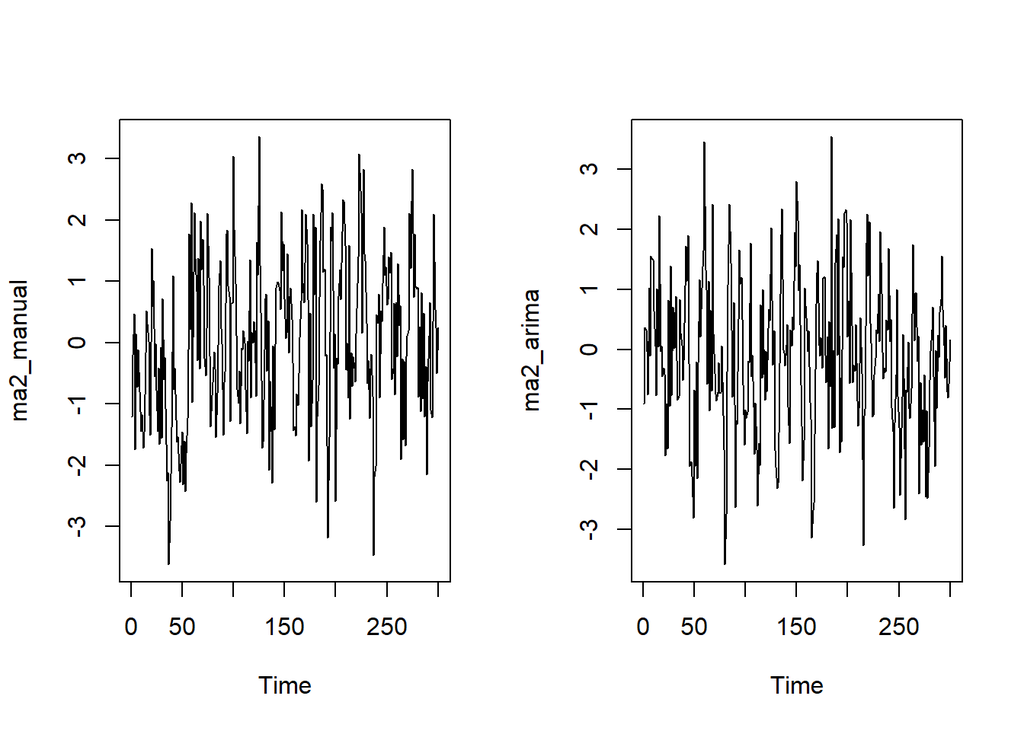

```r
par(mfrow = c(1, 2))
ts.plot(ma2_manual)
ts.plot(ma2_arima)
```

Berdasarkan plot time series, terlihat bahwa data MA(2) berfluktuasi di sekitar nilai rata-rata yang relatif konstan dan tidak menunjukkan adanya tren yang jelas sehingga data dapat dikatakan **stasioner** dalam rataan.

### Plot ACF

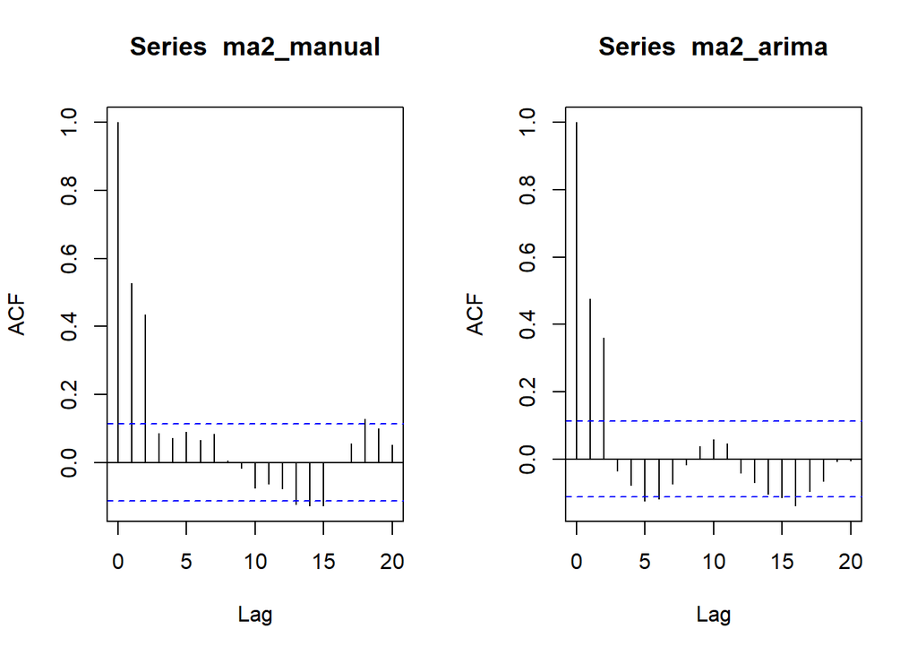

```r
par(mfrow = c(1, 2))
acf(ma2_manual,lag.max = 20)
acf(ma2_arima,lag.max = 20)
```

Berdasarkan plot ACF tersebut, terlihat bahwa plot ACF cuts off pada lag kedua, yang ditunjukkan oleh adanya autokorelasi yang signifikan pada lag ke-2. Setelah lag ke-2, nilai ACF sebagian besar berada di dalam batas signifikansi sehingga tidak menunjukkan autokorelasi yang signifikan. Pola ini menunjukkan bahwa data time series cenderung stasioner dan mengindikasikan model MA(2).

### Plot PACF

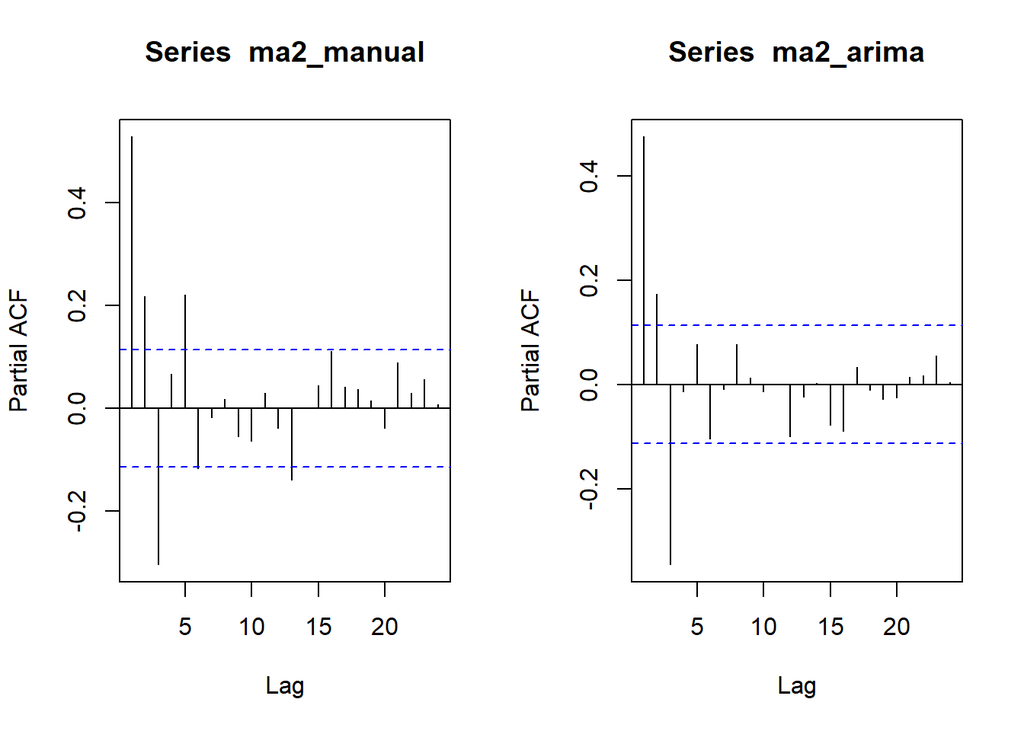

```r
par(mfrow = c(1, 2))
pacf(ma2_manual)
pacf(ma2_arima)
```

Berdasarkan plot PACF, terlihat bahwa plot PACF cenderung tails off. Terdapat beberapa spike yang melewati batas signifikansi pada beberapa lag awal, kemudian sebagian besar nilai PACF berada di dalam batas signifikansi. Pola tails off ini sesuai dengan karakteristik model MA(2).

### Plot EACF

```r
TSA::eacf(ma2_manual)
```

```
## AR/MA
##   0 1 2 3 4 5 6 7 8 9 10 11 12 13
## 0 x x o o o o o o o o o  o  x  x
## 1 x x x o o o o o o o o  o  o  o
## 2 x x x x o o o o o o o  o  o  o
## 3 x x x x x o o o o o o  o  o  o
## 4 x x x x x o o o o o o  o  o  o
## 5 x x o x x o x o o o o  o  o  o
## 6 x x x o x o o x o o o  o  o  o
## 7 x o x o x o o x o o o  o  o  o
```

```r
TSA::eacf(ma2_arima)
```

```
## AR/MA
##   0 1 2 3 4 5 6 7 8 9 10 11 12 13
## 0 x x o o x x o o o o o  o  o  o
## 1 x x x o o o o o o o o  o  o  o
## 2 x x x o o o o o o o o  o  o  o
## 3 o x x x o o o o o o o  o  o  o
## 4 x o x x x o o o o o o  o  o  o
## 5 x x x x x x o o o o o  o  o  o
## 6 o x x x o o o o o o o  o  o  o
## 7 x x x x o o o o o o o  o  o  o
```

Berdasarkan pola segitiga nol pada plot EACF, terlihat bahwa segitiga nol berada pada ordo ar(0) dan ordo MA(2)

### Kesimpulan

Berdasarkan hasil plot time series, ACF, PACF, dan EACF dapat disimpulkan bahwa data MA(2) **bersifat stasioner** karena pada plot time series data berfluktuasi di sekitar nilai rata-rata yang relatif konstan dan tidak menunjukkan tren yang jelas. Plot ACF *cuts off* pada lag kedua, Plot PACF mengalami *tails off*. Sementara itu, pola segitiga nol pada EACF menunjukkan ordo ar(0) dan MA(2), sehingga model yang sesuai adalah MA(2) atau AR(0,2)

## Scatterplot & Auto korelasi Antar Lag

### Yt dengan Yt−1

#### Plot

```r
par(mfrow = c(1, 2))
#Yt
yt_ma2_manual <- ma2_manual[-1]
yt_ma2_manual
```

```
##   [1] -0.205397058  0.471173424 -1.745463687  0.141510314 -0.729712854
##   [6] -0.114842790 -0.472894305 -1.127948717 -1.443797742 -1.171879031
##  [11] -1.723286222 -1.461924092 -0.845074607  0.519525249  0.312187420
##  [16]  0.020572732 -1.181770516 -1.508255550  1.534249256  0.598119283
##  [21]  1.012450498 -0.556369299 -0.011041246 -0.774213194 -1.449939345
##  [26] -0.420758391 -1.662676381 -0.079747157 -1.556197355  0.718835126
##  [31] -0.596243221 -0.238298741 -1.070389923 -2.255260716 -2.120011486
##  [36] -3.624543435 -2.913580609 -2.138714925 -1.388210999  1.086560934
##  [41] -0.768382742 -0.413123964 -1.263954490 -1.619808057 -1.534624150
##  [46] -2.091327966 -2.276021753 -1.689013389 -1.457572736 -2.319068111
##  [51] -1.602598402 -2.425338748 -1.807763414 -1.233628102 -0.110845196
##  [56]  1.775654086  0.223607057  2.285258743 -0.979456751  1.157010823
##  [61]  2.116941328  1.378789117  0.845856907 -0.296314421  1.372262398
##  [66] -0.432336811  1.978634754  1.193531021  1.688995021  0.939220832
##  [71] -0.250827924 -0.544575725  0.228395751  2.109671129  1.063681873
```

[output cut: 45 more lines]

```r
#Yt-1
yt_1_ma2_manual <- ma2_manual[-300]
yt_1_ma2_manual
```

```
##   [1] -1.207065749 -0.205397058  0.471173424 -1.745463687  0.141510314
##   [6] -0.729712854 -0.114842790 -0.472894305 -1.127948717 -1.443797742
##  [11] -1.171879031 -1.723286222 -1.461924092 -0.845074607  0.519525249
##  [16]  0.312187420  0.020572732 -1.181770516 -1.508255550  1.534249256
##  [21]  0.598119283  1.012450498 -0.556369299 -0.011041246 -0.774213194
##  [26] -1.449939345 -0.420758391 -1.662676381 -0.079747157 -1.556197355
##  [31]  0.718835126 -0.596243221 -0.238298741 -1.070389923 -2.255260716
##  [36] -2.120011486 -3.624543435 -2.913580609 -2.138714925 -1.388210999
##  [41]  1.086560934 -0.768382742 -0.413123964 -1.263954490 -1.619808057
##  [46] -1.534624150 -2.091327966 -2.276021753 -1.689013389 -1.457572736
##  [51] -2.319068111 -1.602598402 -2.425338748 -1.807763414 -1.233628102
##  [56] -0.110845196  1.775654086  0.223607057  2.285258743 -0.979456751
##  [61]  1.157010823  2.116941328  1.378789117  0.845856907 -0.296314421
##  [66]  1.372262398 -0.432336811  1.978634754  1.193531021  1.688995021
##  [71]  0.939220832 -0.250827924 -0.544575725  0.228395751  2.109671129
```

[output cut: 45 more lines]

```r
plot(y=yt_ma2_manual,x=yt_1_ma2_manual)

#Yt
yt_ma2_arima <- ma2_arima[-1]
yt_ma2_arima
```

```
##   [1]  0.366069559  0.319892749 -0.033692645 -0.749809541  1.023224875
##   [6] -0.103827746  1.553027734  1.508813504  1.490258435  0.638775303
##  [11]  0.057508568 -0.761313741  1.006804154  0.046165301  2.226792228
##  [16] -0.031351321  0.058227766 -0.452682262 -0.306828839 -0.408896770
##  [21] -1.768664231 -0.905163217 -1.653388217  0.814020129 -0.949587092
##  [26]  1.394975120 -0.770061199  0.708742509  0.626264945  0.016220780
##  [31]  0.886163244 -0.177443664 -0.837739266 -0.776948985  0.830630275
##  [36]  0.271737011  0.068438994 -0.509614613 -0.182137038  1.054967504
##  [41]  1.724174690  1.131301118  1.891160132 -0.238116411 -1.951472236
##  [46] -1.868044756 -2.111236903 -2.805388403 -0.673455997 -1.948408128
##  [51] -0.202080988 -2.147789666 -0.222949385  1.157974906  0.206928218
##  [56]  0.670946455  1.376843234  1.645766212  3.455813794  1.320279510
##  [61]  0.993481981 -0.573676112  1.139365011 -1.017788045  0.653723024
##  [66] -0.694895967  2.417702916  0.264911871 -0.401396581 -0.735903736
##  [71] -0.852168890 -0.715405484 -0.227148156 -0.726083352 -0.709593887
```

[output cut: 45 more lines]

```r
#Yt-1
yt_1_ma2_arima <- ma2_arima[-300]
yt_1_ma2_arima
```

```
##   [1] -0.908714261  0.366069559  0.319892749 -0.033692645 -0.749809541
##   [6]  1.023224875 -0.103827746  1.553027734  1.508813504  1.490258435
##  [11]  0.638775303  0.057508568 -0.761313741  1.006804154  0.046165301
##  [16]  2.226792228 -0.031351321  0.058227766 -0.452682262 -0.306828839
##  [21] -0.408896770 -1.768664231 -0.905163217 -1.653388217  0.814020129
##  [26] -0.949587092  1.394975120 -0.770061199  0.708742509  0.626264945
##  [31]  0.016220780  0.886163244 -0.177443664 -0.837739266 -0.776948985
##  [36]  0.830630275  0.271737011  0.068438994 -0.509614613 -0.182137038
##  [41]  1.054967504  1.724174690  1.131301118  1.891160132 -0.238116411
##  [46] -1.951472236 -1.868044756 -2.111236903 -2.805388403 -0.673455997
##  [51] -1.948408128 -0.202080988 -2.147789666 -0.222949385  1.157974906
##  [56]  0.206928218  0.670946455  1.376843234  1.645766212  3.455813794
##  [61]  1.320279510  0.993481981 -0.573676112  1.139365011 -1.017788045
##  [66]  0.653723024 -0.694895967  2.417702916  0.264911871 -0.401396581
##  [71] -0.735903736 -0.852168890 -0.715405484 -0.227148156 -0.726083352
```

[output cut: 45 more lines]

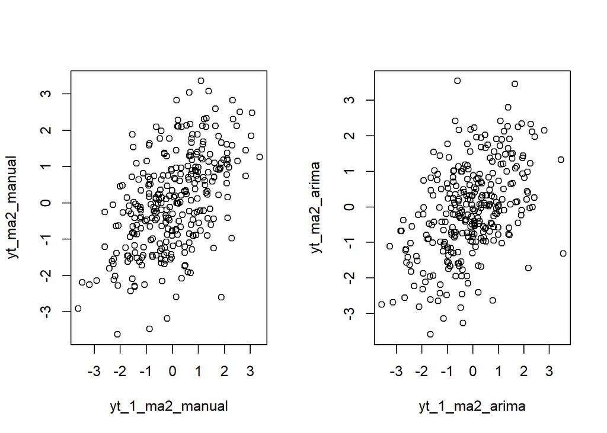

```r
plot(y=yt_ma2_arima,x=yt_1_ma2_arima)
```

#### Korelasi

```r
cor(yt_ma2_manual,yt_1_ma2_manual)
```

```
## [1] 0.5282201
```

```r
cor(yt_ma2_arima,yt_1_ma2_arima)
```

```
## [1] 0.4750929
```

Korelasi antara Yt dengan Yt−1 dari hasil simulasi mendekati perhitungan teoritis yaitu
$$\rho_1=\frac{0.4+(0.4)(0.6)}{1+(0.4)^2+(0.6)^2}
=\frac{0.64}{1.52}
=0.421$$

### Yt dengan Yt−2

#### Plot

```r
par(mfrow = c(1, 2))
#Yt
yt_ma2_manual_lag2 <- ma2_manual[-c(1,2)]
yt_ma2_manual_lag2
```

```
##   [1]  0.471173424 -1.745463687  0.141510314 -0.729712854 -0.114842790
##   [6] -0.472894305 -1.127948717 -1.443797742 -1.171879031 -1.723286222
##  [11] -1.461924092 -0.845074607  0.519525249  0.312187420  0.020572732
##  [16] -1.181770516 -1.508255550  1.534249256  0.598119283  1.012450498
##  [21] -0.556369299 -0.011041246 -0.774213194 -1.449939345 -0.420758391
##  [26] -1.662676381 -0.079747157 -1.556197355  0.718835126 -0.596243221
##  [31] -0.238298741 -1.070389923 -2.255260716 -2.120011486 -3.624543435
##  [36] -2.913580609 -2.138714925 -1.388210999  1.086560934 -0.768382742
##  [41] -0.413123964 -1.263954490 -1.619808057 -1.534624150 -2.091327966
##  [46] -2.276021753 -1.689013389 -1.457572736 -2.319068111 -1.602598402
##  [51] -2.425338748 -1.807763414 -1.233628102 -0.110845196  1.775654086
##  [56]  0.223607057  2.285258743 -0.979456751  1.157010823  2.116941328
##  [61]  1.378789117  0.845856907 -0.296314421  1.372262398 -0.432336811
##  [66]  1.978634754  1.193531021  1.688995021  0.939220832 -0.250827924
##  [71] -0.544575725  0.228395751  2.109671129  1.063681873 -0.209897795
```

[output cut: 45 more lines]

```r
# Yt-2
yt_2_ma2_manual <- ma2_manual[-c(299, 300)]
yt_2_ma2_manual
```

```
##   [1] -1.207065749 -0.205397058  0.471173424 -1.745463687  0.141510314
##   [6] -0.729712854 -0.114842790 -0.472894305 -1.127948717 -1.443797742
##  [11] -1.171879031 -1.723286222 -1.461924092 -0.845074607  0.519525249
##  [16]  0.312187420  0.020572732 -1.181770516 -1.508255550  1.534249256
##  [21]  0.598119283  1.012450498 -0.556369299 -0.011041246 -0.774213194
##  [26] -1.449939345 -0.420758391 -1.662676381 -0.079747157 -1.556197355
##  [31]  0.718835126 -0.596243221 -0.238298741 -1.070389923 -2.255260716
##  [36] -2.120011486 -3.624543435 -2.913580609 -2.138714925 -1.388210999
##  [41]  1.086560934 -0.768382742 -0.413123964 -1.263954490 -1.619808057
##  [46] -1.534624150 -2.091327966 -2.276021753 -1.689013389 -1.457572736
##  [51] -2.319068111 -1.602598402 -2.425338748 -1.807763414 -1.233628102
##  [56] -0.110845196  1.775654086  0.223607057  2.285258743 -0.979456751
##  [61]  1.157010823  2.116941328  1.378789117  0.845856907 -0.296314421
##  [66]  1.372262398 -0.432336811  1.978634754  1.193531021  1.688995021
##  [71]  0.939220832 -0.250827924 -0.544575725  0.228395751  2.109671129
```

[output cut: 45 more lines]

```r
plot(y=yt_ma2_manual_lag2,x=yt_2_ma2_manual)

#Yt
yt_ma2_arima_lag2 <- ma2_arima[-c(1,2)]
yt_ma2_arima_lag2
```

```
##   [1]  0.319892749 -0.033692645 -0.749809541  1.023224875 -0.103827746
##   [6]  1.553027734  1.508813504  1.490258435  0.638775303  0.057508568
##  [11] -0.761313741  1.006804154  0.046165301  2.226792228 -0.031351321
##  [16]  0.058227766 -0.452682262 -0.306828839 -0.408896770 -1.768664231
##  [21] -0.905163217 -1.653388217  0.814020129 -0.949587092  1.394975120
##  [26] -0.770061199  0.708742509  0.626264945  0.016220780  0.886163244
##  [31] -0.177443664 -0.837739266 -0.776948985  0.830630275  0.271737011
##  [36]  0.068438994 -0.509614613 -0.182137038  1.054967504  1.724174690
##  [41]  1.131301118  1.891160132 -0.238116411 -1.951472236 -1.868044756
##  [46] -2.111236903 -2.805388403 -0.673455997 -1.948408128 -0.202080988
##  [51] -2.147789666 -0.222949385  1.157974906  0.206928218  0.670946455
##  [56]  1.376843234  1.645766212  3.455813794  1.320279510  0.993481981
##  [61] -0.573676112  1.139365011 -1.017788045  0.653723024 -0.694895967
##  [66]  2.417702916  0.264911871 -0.401396581 -0.735903736 -0.852168890
##  [71] -0.715405484 -0.227148156 -0.726083352 -0.709593887  0.064017627
```

[output cut: 45 more lines]

```r
# Yt-2
yt_2_ma2_arima <- ma2_arima[-c(299, 300)]
yt_2_ma2_arima
```

```
##   [1] -0.908714261  0.366069559  0.319892749 -0.033692645 -0.749809541
##   [6]  1.023224875 -0.103827746  1.553027734  1.508813504  1.490258435
##  [11]  0.638775303  0.057508568 -0.761313741  1.006804154  0.046165301
##  [16]  2.226792228 -0.031351321  0.058227766 -0.452682262 -0.306828839
##  [21] -0.408896770 -1.768664231 -0.905163217 -1.653388217  0.814020129
##  [26] -0.949587092  1.394975120 -0.770061199  0.708742509  0.626264945
##  [31]  0.016220780  0.886163244 -0.177443664 -0.837739266 -0.776948985
##  [36]  0.830630275  0.271737011  0.068438994 -0.509614613 -0.182137038
##  [41]  1.054967504  1.724174690  1.131301118  1.891160132 -0.238116411
##  [46] -1.951472236 -1.868044756 -2.111236903 -2.805388403 -0.673455997
##  [51] -1.948408128 -0.202080988 -2.147789666 -0.222949385  1.157974906
##  [56]  0.206928218  0.670946455  1.376843234  1.645766212  3.455813794
##  [61]  1.320279510  0.993481981 -0.573676112  1.139365011 -1.017788045
##  [66]  0.653723024 -0.694895967  2.417702916  0.264911871 -0.401396581
##  [71] -0.735903736 -0.852168890 -0.715405484 -0.227148156 -0.726083352
```

[output cut: 45 more lines]

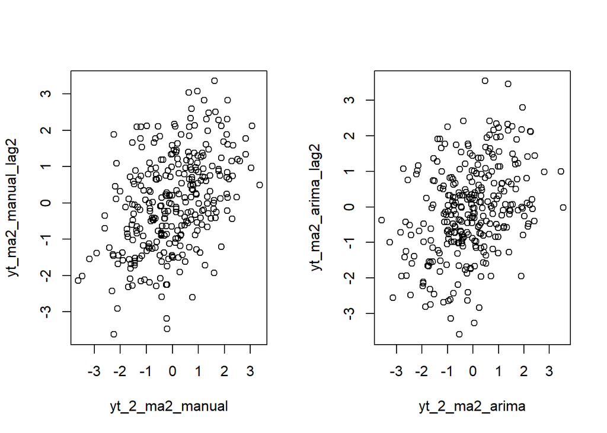

```r
plot(y=yt_ma2_arima_lag2,x=yt_2_ma2_arima)
```

#### Korelasi

```r
cor(yt_ma2_manual_lag2,yt_2_ma2_manual)
```

```
## [1] 0.4356204
```

```r
cor(yt_ma2_arima_lag2,yt_2_ma2_arima)
```

```
## [1] 0.3599318
```

Korelasi antara Yt dengan Yt−2 dari hasil simulasi mendekati perhitungan teoritis yaitu
$$\rho_2=\frac{(0.6)}{1+(0.4)^2+(0.6)^2}
=\frac{0.6}{1.52}
=0.3947$$

### Yt dengan Yt−3

#### Plot

```r
par(mfrow = c(1, 2))
#Yt
yt_ma2_manual_lag3 <- ma2_manual[-c(1,2,3)]
yt_ma2_manual_lag3
```

```
##   [1] -1.745463687  0.141510314 -0.729712854 -0.114842790 -0.472894305
##   [6] -1.127948717 -1.443797742 -1.171879031 -1.723286222 -1.461924092
##  [11] -0.845074607  0.519525249  0.312187420  0.020572732 -1.181770516
##  [16] -1.508255550  1.534249256  0.598119283  1.012450498 -0.556369299
##  [21] -0.011041246 -0.774213194 -1.449939345 -0.420758391 -1.662676381
##  [26] -0.079747157 -1.556197355  0.718835126 -0.596243221 -0.238298741
##  [31] -1.070389923 -2.255260716 -2.120011486 -3.624543435 -2.913580609
##  [36] -2.138714925 -1.388210999  1.086560934 -0.768382742 -0.413123964
##  [41] -1.263954490 -1.619808057 -1.534624150 -2.091327966 -2.276021753
##  [46] -1.689013389 -1.457572736 -2.319068111 -1.602598402 -2.425338748
##  [51] -1.807763414 -1.233628102 -0.110845196  1.775654086  0.223607057
##  [56]  2.285258743 -0.979456751  1.157010823  2.116941328  1.378789117
##  [61]  0.845856907 -0.296314421  1.372262398 -0.432336811  1.978634754
##  [66]  1.193531021  1.688995021  0.939220832 -0.250827924 -0.544575725
##  [71]  0.228395751  2.109671129  1.063681873 -0.209897795 -1.371901203
```

[output cut: 45 more lines]

```r
# Yt-3
yt_3_ma2_manual <- ma2_manual[-c(298,299, 300)]
yt_3_ma2_manual
```

```
##   [1] -1.207065749 -0.205397058  0.471173424 -1.745463687  0.141510314
##   [6] -0.729712854 -0.114842790 -0.472894305 -1.127948717 -1.443797742
##  [11] -1.171879031 -1.723286222 -1.461924092 -0.845074607  0.519525249
##  [16]  0.312187420  0.020572732 -1.181770516 -1.508255550  1.534249256
##  [21]  0.598119283  1.012450498 -0.556369299 -0.011041246 -0.774213194
##  [26] -1.449939345 -0.420758391 -1.662676381 -0.079747157 -1.556197355
##  [31]  0.718835126 -0.596243221 -0.238298741 -1.070389923 -2.255260716
##  [36] -2.120011486 -3.624543435 -2.913580609 -2.138714925 -1.388210999
##  [41]  1.086560934 -0.768382742 -0.413123964 -1.263954490 -1.619808057
##  [46] -1.534624150 -2.091327966 -2.276021753 -1.689013389 -1.457572736
##  [51] -2.319068111 -1.602598402 -2.425338748 -1.807763414 -1.233628102
##  [56] -0.110845196  1.775654086  0.223607057  2.285258743 -0.979456751
##  [61]  1.157010823  2.116941328  1.378789117  0.845856907 -0.296314421
##  [66]  1.372262398 -0.432336811  1.978634754  1.193531021  1.688995021
##  [71]  0.939220832 -0.250827924 -0.544575725  0.228395751  2.109671129
```

[output cut: 45 more lines]

```r
plot(y=yt_ma2_manual_lag3,x=yt_3_ma2_manual)

#Yt
yt_ma2_arima_lag3 <- ma2_arima[-c(1,2,3)]
yt_ma2_arima_lag3
```

```
##   [1] -0.033692645 -0.749809541  1.023224875 -0.103827746  1.553027734
##   [6]  1.508813504  1.490258435  0.638775303  0.057508568 -0.761313741
##  [11]  1.006804154  0.046165301  2.226792228 -0.031351321  0.058227766
##  [16] -0.452682262 -0.306828839 -0.408896770 -1.768664231 -0.905163217
##  [21] -1.653388217  0.814020129 -0.949587092  1.394975120 -0.770061199
##  [26]  0.708742509  0.626264945  0.016220780  0.886163244 -0.177443664
##  [31] -0.837739266 -0.776948985  0.830630275  0.271737011  0.068438994
##  [36] -0.509614613 -0.182137038  1.054967504  1.724174690  1.131301118
##  [41]  1.891160132 -0.238116411 -1.951472236 -1.868044756 -2.111236903
##  [46] -2.805388403 -0.673455997 -1.948408128 -0.202080988 -2.147789666
##  [51] -0.222949385  1.157974906  0.206928218  0.670946455  1.376843234
##  [56]  1.645766212  3.455813794  1.320279510  0.993481981 -0.573676112
##  [61]  1.139365011 -1.017788045  0.653723024 -0.694895967  2.417702916
##  [66]  0.264911871 -0.401396581 -0.735903736 -0.852168890 -0.715405484
##  [71] -0.227148156 -0.726083352 -0.709593887  0.064017627 -0.538583124
```

[output cut: 45 more lines]

```r
# Yt-3
yt_3_ma2_arima <- ma2_arima[-c(298,299, 300)]
yt_3_ma2_arima
```

```
##   [1] -0.908714261  0.366069559  0.319892749 -0.033692645 -0.749809541
##   [6]  1.023224875 -0.103827746  1.553027734  1.508813504  1.490258435
##  [11]  0.638775303  0.057508568 -0.761313741  1.006804154  0.046165301
##  [16]  2.226792228 -0.031351321  0.058227766 -0.452682262 -0.306828839
##  [21] -0.408896770 -1.768664231 -0.905163217 -1.653388217  0.814020129
##  [26] -0.949587092  1.394975120 -0.770061199  0.708742509  0.626264945
##  [31]  0.016220780  0.886163244 -0.177443664 -0.837739266 -0.776948985
##  [36]  0.830630275  0.271737011  0.068438994 -0.509614613 -0.182137038
##  [41]  1.054967504  1.724174690  1.131301118  1.891160132 -0.238116411
##  [46] -1.951472236 -1.868044756 -2.111236903 -2.805388403 -0.673455997
##  [51] -1.948408128 -0.202080988 -2.147789666 -0.222949385  1.157974906
##  [56]  0.206928218  0.670946455  1.376843234  1.645766212  3.455813794
##  [61]  1.320279510  0.993481981 -0.573676112  1.139365011 -1.017788045
##  [66]  0.653723024 -0.694895967  2.417702916  0.264911871 -0.401396581
##  [71] -0.735903736 -0.852168890 -0.715405484 -0.227148156 -0.726083352
```

[output cut: 45 more lines]

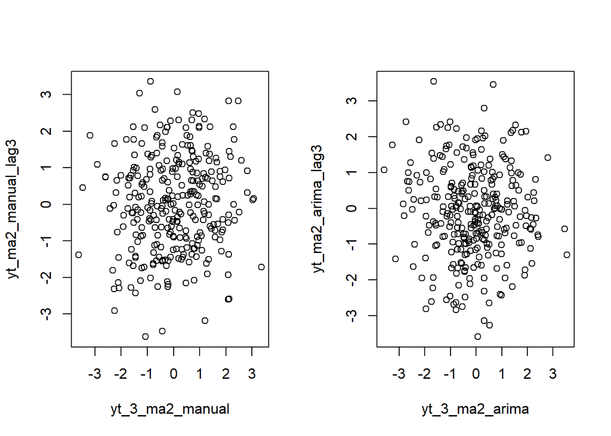

```r
plot(y=yt_ma2_arima_lag3,x=yt_3_ma2_arima)
```

#### Korelasi

```r
cor(yt_ma2_manual_lag3,yt_3_ma2_manual)
```

```
## [1] 0.08544546
```

```r
cor(yt_ma2_arima_lag3,yt_3_ma2_manual)
```

```
## [1] -0.0296439
```

# Proses ar(2)

Membangkitkan Model ar(2)  
Dalam kasus ini, akan dibangkitkan suatu data dengan model ar(2) sebanyak 300 data yang memiliki nilai ϕ1=0.5 dan ϕ2=0.2. Rumusan model tersebut adalah sebagai berikut

$Y_t = \varepsilon_t + 0.5Y_{t-1} + 0.2Y_{t-2}$

## Membangkitkan Model AR(2)

### Manual

```r
set.seed(1051)
n<-length(wn)
n
```

```
## [1] 300
```

```r
ar2_manual <- c(1:n)
ar2_manual[1] <- wn[1]
ar2_manual[2] <- wn[2] + 0.5 * ar2_manual[1]
for (i in 3:n) {
  ar2_manual[i] <- wn[i] + 0.5 * ar2_manual[i-1] + 0.2 * ar2_manual[i-2]
}
ar2_manual
```

```
##   [1] -1.207065749 -0.326103633  0.679976211 -2.070930324 -0.470345231
##   [6] -0.143302788 -0.740460400 -0.945522614 -1.185305386 -1.671795045
##  [11] -1.550151299 -2.107821103 -2.140194706 -1.427202757 -0.182146261
##  [16] -0.486799176 -0.790838346 -1.403974425 -1.697326562  1.286377013
##  [21]  0.437811414 -0.014504787 -0.360237983  0.276569492 -0.627483098
##  [26] -1.706632561 -0.404057179 -1.567010825 -0.879455148 -1.689078340
##  [31]  0.081867346 -0.772475074 -1.079304105 -1.195405128 -2.442656854
##  [36] -2.628028715 -3.982585377 -3.857891624 -3.019756746 -2.747354238
##  [41] -0.528132203 -1.882179673 -1.902080911 -1.608099392 -2.178805954
##  [46] -2.379537173 -2.732847970 -3.094317305 -2.617556366 -2.424491601
##  [51] -3.541788331 -2.837868410 -3.236181496 -3.200626439 -2.409859042
##  [56] -1.281998990  0.524846169 -0.767330137  1.327213794 -0.647667678
##  [61]  0.598197384  2.718556227  1.444157201  0.596156266  0.579304817
##  [66]  2.185968110  0.070237282  1.840139442  2.263681968  1.836341670
##  [71]  1.377800067  0.600699629  0.209385895  0.873119441  2.548707761
```

[output cut: 45 more lines]

### arima.sim

```r
ar2_arima <- arima.sim(list(order=c(2,0,0), ar=c(0.5,0.2)), n=300)
ar2_arima
```

```
## Time Series:
## Start = 1
## End = 300
## Frequency = 1
##   [1]  1.172148447 -0.437733455 -1.926194858 -1.784562216 -2.074856748
##   [6] -0.603346856  0.115336517  1.979928265  0.519205299 -0.696176184
##  [11] -1.468891852 -1.927645533 -0.617721121 -3.073969845 -1.105255535
##  [16] -1.544078453 -0.780667738 -1.441119681 -2.237546251 -1.120567457
##  [21] -2.338668243 -1.598298743 -1.702689791 -2.250655081 -2.969989827
##  [26] -1.661653202 -0.190403943  0.288746608  0.192231777 -0.568477298
##  [31] -2.040429169 -1.485135159 -0.811636997 -0.443239566  0.675068462
##  [36]  1.054017939  2.125241038 -0.883076182 -1.671984404 -2.580559885
##  [41] -2.313009738 -1.734646274 -2.008357108 -0.008284272 -1.275232709
##  [46] -1.213701396 -0.652328651 -0.555429203  0.665476831  0.487308486
##  [51] -1.231349306 -1.620098695 -1.397786958 -0.680197409 -0.629349571
```

[output cut: 49 more lines]

## Karakteristik AR (2)

### Plot Time Series

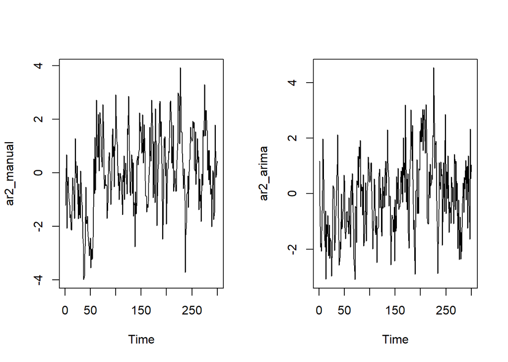

```r
par(mfrow = c(1, 2))
ts.plot(ar2_manual)
ts.plot(ar2_arima)
```

Berdasarkan plot time series tersebut terlihat bahwa data cenderung stasioner pada rataan

### Plot ACF

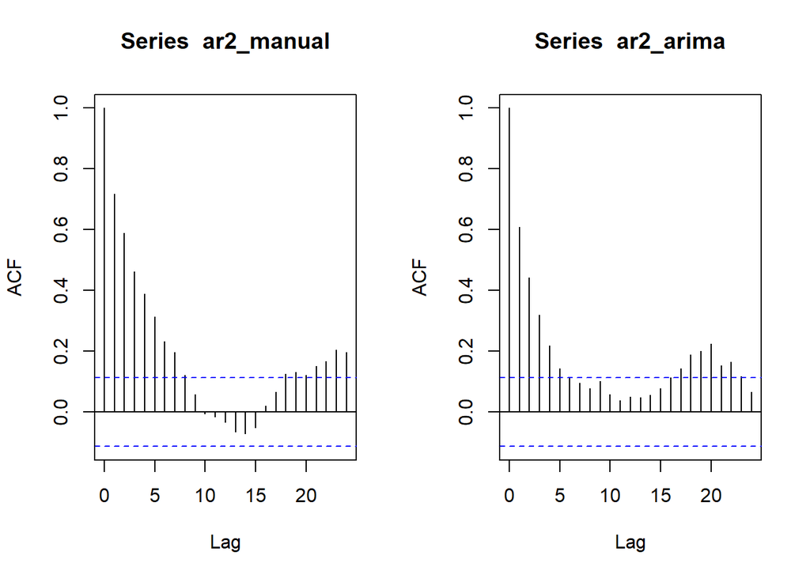

```r
par(mfrow = c(1, 2))
acf(ar2_manual)
acf(ar2_arima)
```

Berdasarkan plot ACF, terlihat bahwa nilai autokorelasi cenderung tails off, yaitu menurun secara bertahap menuju nol, kemudian berfluktuasi di sekitar nol dan membentuk pola osilasi pada beberapa lag berikutnya.

### Plot PACF

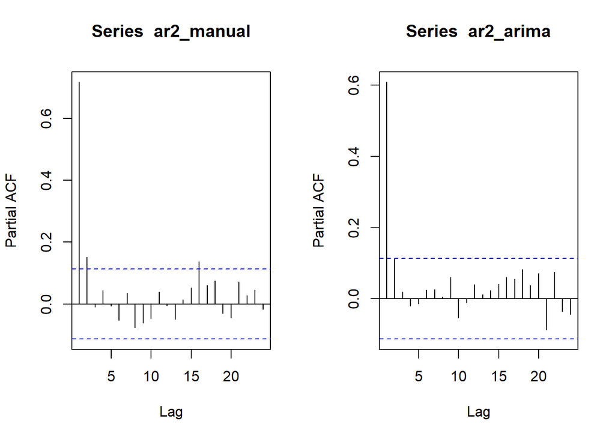

```r
par(mfrow = c(1, 2))
pacf(ar2_manual)
pacf(ar2_arima)
```

### Plot EACF

```r
TSA::eacf(ar2_manual)
```

```
## AR/MA
##   0 1 2 3 4 5 6 7 8 9 10 11 12 13
## 0 x x x x x x x x o o o  o  o  o
## 1 x o o o o o o o o o o  o  o  o
## 2 o o o o o o o o o o o  o  o  o
## 3 x x o o o o o o o o o  o  o  o
## 4 x x o o o o o o o o o  o  o  o
## 5 o x o x o o x o o o o  o  o  o
## 6 x x x x o o o o o o o  o  o  o
## 7 x x x o x x o o o o o  o  o  o
```

```r
TSA::eacf(ar2_arima)
```

```
## AR/MA
##   0 1 2 3 4 5 6 7 8 9 10 11 12 13
## 0 x x x x x o o o o o o  o  o  o
## 1 x o o o o o o o o o o  o  o  o
## 2 x o o o o o o o o o o  o  o  o
## 3 x x o o o o o o o o o  o  o  o
## 4 x x o o o o o o o o o  o  o  o
## 5 x x x o o o o o o o o  o  o  o
## 6 x x o o o o o o o o o  o  o  o
## 7 x x o x o o o o o o o  o  o  o
```

## Scatterplot & Auto korelasi Antar Lag

### Yt dengan Yt−1

#### Plot

```r
par(mfrow = c(1, 2))
#Yt
yt_ar2_manual <- ar2_manual[-1]
yt_ar2_manual
```

```
##   [1] -0.326103633  0.679976211 -2.070930324 -0.470345231 -0.143302788
##   [6] -0.740460400 -0.945522614 -1.185305386 -1.671795045 -1.550151299
##  [11] -2.107821103 -2.140194706 -1.427202757 -0.182146261 -0.486799176
##  [16] -0.790838346 -1.403974425 -1.697326562  1.286377013  0.437811414
##  [21] -0.014504787 -0.360237983  0.276569492 -0.627483098 -1.706632561
##  [26] -0.404057179 -1.567010825 -0.879455148 -1.689078340  0.081867346
##  [31] -0.772475074 -1.079304105 -1.195405128 -2.442656854 -2.628028715
##  [36] -3.982585377 -3.857891624 -3.019756746 -2.747354238 -0.528132203
##  [41] -1.882179673 -1.902080911 -1.608099392 -2.178805954 -2.379537173
##  [46] -2.732847970 -3.094317305 -2.617556366 -2.424491601 -3.541788331
##  [51] -2.837868410 -3.236181496 -3.200626439 -2.409859042 -1.281998990
##  [56]  0.524846169 -0.767330137  1.327213794 -0.647667678  0.598197384
##  [61]  2.718556227  1.444157201  0.596156266  0.579304817  2.185968110
##  [66]  0.070237282  1.840139442  2.263681968  1.836341670  1.377800067
##  [71]  0.600699629  0.209385895  0.873119441  2.548707761  1.295579356
```

[output cut: 45 more lines]

```r
#Yt-1
yt_1_ar2_manual <- ar2_manual[-300]
yt_1_ar2_manual
```

```
##   [1] -1.207065749 -0.326103633  0.679976211 -2.070930324 -0.470345231
##   [6] -0.143302788 -0.740460400 -0.945522614 -1.185305386 -1.671795045
##  [11] -1.550151299 -2.107821103 -2.140194706 -1.427202757 -0.182146261
##  [16] -0.486799176 -0.790838346 -1.403974425 -1.697326562  1.286377013
##  [21]  0.437811414 -0.014504787 -0.360237983  0.276569492 -0.627483098
##  [26] -1.706632561 -0.404057179 -1.567010825 -0.879455148 -1.689078340
##  [31]  0.081867346 -0.772475074 -1.079304105 -1.195405128 -2.442656854
##  [36] -2.628028715 -3.982585377 -3.857891624 -3.019756746 -2.747354238
##  [41] -0.528132203 -1.882179673 -1.902080911 -1.608099392 -2.178805954
##  [46] -2.379537173 -2.732847970 -3.094317305 -2.617556366 -2.424491601
##  [51] -3.541788331 -2.837868410 -3.236181496 -3.200626439 -2.409859042
##  [56] -1.281998990  0.524846169 -0.767330137  1.327213794 -0.647667678
##  [61]  0.598197384  2.718556227  1.444157201  0.596156266  0.579304817
##  [66]  2.185968110  0.070237282  1.840139442  2.263681968  1.836341670
##  [71]  1.377800067  0.600699629  0.209385895  0.873119441  2.548707761
```

[output cut: 45 more lines]

```r
plot(y=yt_ar2_manual,x=yt_1_ar2_manual)

#Yt
yt_ar2_arima <- ar2_arima[-1]
yt_ar2_arima
```

```
##   [1] -0.437733455 -1.926194858 -1.784562216 -2.074856748 -0.603346856
##   [6]  0.115336517  1.979928265  0.519205299 -0.696176184 -1.468891852
##  [11] -1.927645533 -0.617721121 -3.073969845 -1.105255535 -1.544078453
##  [16] -0.780667738 -1.441119681 -2.237546251 -1.120567457 -2.338668243
##  [21] -1.598298743 -1.702689791 -2.250655081 -2.969989827 -1.661653202
##  [26] -0.190403943  0.288746608  0.192231777 -0.568477298 -2.040429169
##  [31] -1.485135159 -0.811636997 -0.443239566  0.675068462  1.054017939
##  [36]  2.125241038 -0.883076182 -1.671984404 -2.580559885 -2.313009738
##  [41] -1.734646274 -2.008357108 -0.008284272 -1.275232709 -1.213701396
##  [46] -0.652328651 -0.555429203  0.665476831  0.487308486 -1.231349306
##  [51] -1.620098695 -1.397786958 -0.680197409 -0.629349571 -1.020774866
##  [56] -0.975089143 -1.448311341 -0.144248036 -0.782066972 -1.452734085
##  [61] -1.920048812  0.106817503  0.488751193 -0.405237469  0.730079241
##  [66] -0.674487846 -1.261319914 -2.357243530 -2.798441847 -3.095940472
##  [71] -0.462035605 -0.500110261 -1.767886587  0.460671138  0.318425904
```

[output cut: 45 more lines]

```r
#Yt-1
yt_1_ar2_arima <- ar2_arima[-300]
yt_1_ar2_arima
```

```
##   [1]  1.172148447 -0.437733455 -1.926194858 -1.784562216 -2.074856748
##   [6] -0.603346856  0.115336517  1.979928265  0.519205299 -0.696176184
##  [11] -1.468891852 -1.927645533 -0.617721121 -3.073969845 -1.105255535
##  [16] -1.544078453 -0.780667738 -1.441119681 -2.237546251 -1.120567457
##  [21] -2.338668243 -1.598298743 -1.702689791 -2.250655081 -2.969989827
##  [26] -1.661653202 -0.190403943  0.288746608  0.192231777 -0.568477298
##  [31] -2.040429169 -1.485135159 -0.811636997 -0.443239566  0.675068462
##  [36]  1.054017939  2.125241038 -0.883076182 -1.671984404 -2.580559885
##  [41] -2.313009738 -1.734646274 -2.008357108 -0.008284272 -1.275232709
##  [46] -1.213701396 -0.652328651 -0.555429203  0.665476831  0.487308486
##  [51] -1.231349306 -1.620098695 -1.397786958 -0.680197409 -0.629349571
##  [56] -1.020774866 -0.975089143 -1.448311341 -0.144248036 -0.782066972
##  [61] -1.452734085 -1.920048812  0.106817503  0.488751193 -0.405237469
##  [66]  0.730079241 -0.674487846 -1.261319914 -2.357243530 -2.798441847
##  [71] -3.095940472 -0.462035605 -0.500110261 -1.767886587  0.460671138
```

[output cut: 45 more lines]

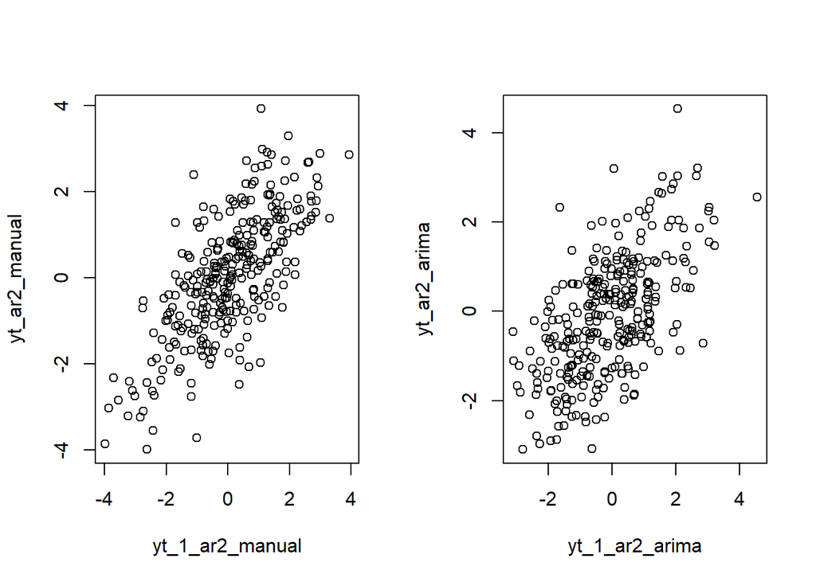

```r
plot(y=yt_ar2_arima,x=yt_1_ar2_arima)
```

Berdasarkan scatterplot tersebut, terlihat bahwa terdapat hubungan positif antara Yt dengan Yt−1. Hal ini sesuai dengan teori yang ada

#### Korelasi

```r
cor(yt_ar2_manual,yt_1_ar2_manual)
```

```
## [1] 0.7181941
```

```r
cor(yt_ar2_arima,yt_1_ar2_arima)
```

```
## [1] 0.6107015
```

Korelasi antara Yt dengan Yt−1 dari hasil simulasi mendekati perhitungan teoritis yaitu

$\rho_1 = \frac{\phi_1}{1 - \phi_2} = \frac{0.5}{1 - 0.2} = 0.625$

### Yt dengan Yt−2

#### Plot

```r
par(mfrow = c(1, 2))
#Yt
yt_ar2_manual_lag2 <- ar2_manual[-c(1,2)]
yt_ar2_manual_lag2
```

```
##   [1]  0.679976211 -2.070930324 -0.470345231 -0.143302788 -0.740460400
##   [6] -0.945522614 -1.185305386 -1.671795045 -1.550151299 -2.107821103
##  [11] -2.140194706 -1.427202757 -0.182146261 -0.486799176 -0.790838346
##  [16] -1.403974425 -1.697326562  1.286377013  0.437811414 -0.014504787
##  [21] -0.360237983  0.276569492 -0.627483098 -1.706632561 -0.404057179
##  [26] -1.567010825 -0.879455148 -1.689078340  0.081867346 -0.772475074
##  [31] -1.079304105 -1.195405128 -2.442656854 -2.628028715 -3.982585377
##  [36] -3.857891624 -3.019756746 -2.747354238 -0.528132203 -1.882179673
##  [41] -1.902080911 -1.608099392 -2.178805954 -2.379537173 -2.732847970
##  [46] -3.094317305 -2.617556366 -2.424491601 -3.541788331 -2.837868410
##  [51] -3.236181496 -3.200626439 -2.409859042 -1.281998990  0.524846169
##  [56] -0.767330137  1.327213794 -0.647667678  0.598197384  2.718556227
##  [61]  1.444157201  0.596156266  0.579304817  2.185968110  0.070237282
##  [66]  1.840139442  2.263681968  1.836341670  1.377800067  0.600699629
##  [71]  0.209385895  0.873119441  2.548707761  1.295579356 -0.233169716
```

[output cut: 45 more lines]

```r
# Yt-2
yt_2_ar2_manual <- ar2_manual[-c(299, 300)]
yt_2_ar2_manual
```

```
##   [1] -1.207065749 -0.326103633  0.679976211 -2.070930324 -0.470345231
##   [6] -0.143302788 -0.740460400 -0.945522614 -1.185305386 -1.671795045
##  [11] -1.550151299 -2.107821103 -2.140194706 -1.427202757 -0.182146261
##  [16] -0.486799176 -0.790838346 -1.403974425 -1.697326562  1.286377013
##  [21]  0.437811414 -0.014504787 -0.360237983  0.276569492 -0.627483098
##  [26] -1.706632561 -0.404057179 -1.567010825 -0.879455148 -1.689078340
##  [31]  0.081867346 -0.772475074 -1.079304105 -1.195405128 -2.442656854
##  [36] -2.628028715 -3.982585377 -3.857891624 -3.019756746 -2.747354238
##  [41] -0.528132203 -1.882179673 -1.902080911 -1.608099392 -2.178805954
##  [46] -2.379537173 -2.732847970 -3.094317305 -2.617556366 -2.424491601
##  [51] -3.541788331 -2.837868410 -3.236181496 -3.200626439 -2.409859042
##  [56] -1.281998990  0.524846169 -0.767330137  1.327213794 -0.647667678
##  [61]  0.598197384  2.718556227  1.444157201  0.596156266  0.579304817
##  [66]  2.185968110  0.070237282  1.840139442  2.263681968  1.836341670
##  [71]  1.377800067  0.600699629  0.209385895  0.873119441  2.548707761
```

[output cut: 45 more lines]

```r
plot(y=yt_ar2_manual_lag2,x=yt_2_ar2_manual)

#Yt
yt_ar2_arima_lag2 <- ar2_arima[-c(1,2)]
yt_ar2_arima_lag2
```

```
##   [1] -1.926194858 -1.784562216 -2.074856748 -0.603346856  0.115336517
##   [6]  1.979928265  0.519205299 -0.696176184 -1.468891852 -1.927645533
##  [11] -0.617721121 -3.073969845 -1.105255535 -1.544078453 -0.780667738
##  [16] -1.441119681 -2.237546251 -1.120567457 -2.338668243 -1.598298743
##  [21] -1.702689791 -2.250655081 -2.969989827 -1.661653202 -0.190403943
##  [26]  0.288746608  0.192231777 -0.568477298 -2.040429169 -1.485135159
##  [31] -0.811636997 -0.443239566  0.675068462  1.054017939  2.125241038
##  [36] -0.883076182 -1.671984404 -2.580559885 -2.313009738 -1.734646274
##  [41] -2.008357108 -0.008284272 -1.275232709 -1.213701396 -0.652328651
##  [46] -0.555429203  0.665476831  0.487308486 -1.231349306 -1.620098695
##  [51] -1.397786958 -0.680197409 -0.629349571 -1.020774866 -0.975089143
##  [56] -1.448311341 -0.144248036 -0.782066972 -1.452734085 -1.920048812
##  [61]  0.106817503  0.488751193 -0.405237469  0.730079241 -0.674487846
##  [66] -1.261319914 -2.357243530 -2.798441847 -3.095940472 -0.462035605
##  [71] -0.500110261 -1.767886587  0.460671138  0.318425904  1.353262104
```

[output cut: 45 more lines]

```r
# Yt-2
yt_2_ar2_arima <- ar2_arima[-c(299, 300)]
yt_2_ar2_arima
```

```
##   [1]  1.172148447 -0.437733455 -1.926194858 -1.784562216 -2.074856748
##   [6] -0.603346856  0.115336517  1.979928265  0.519205299 -0.696176184
##  [11] -1.468891852 -1.927645533 -0.617721121 -3.073969845 -1.105255535
##  [16] -1.544078453 -0.780667738 -1.441119681 -2.237546251 -1.120567457
##  [21] -2.338668243 -1.598298743 -1.702689791 -2.250655081 -2.969989827
##  [26] -1.661653202 -0.190403943  0.288746608  0.192231777 -0.568477298
##  [31] -2.040429169 -1.485135159 -0.811636997 -0.443239566  0.675068462
##  [36]  1.054017939  2.125241038 -0.883076182 -1.671984404 -2.580559885
##  [41] -2.313009738 -1.734646274 -2.008357108 -0.008284272 -1.275232709
##  [46] -1.213701396 -0.652328651 -0.555429203  0.665476831  0.487308486
##  [51] -1.231349306 -1.620098695 -1.397786958 -0.680197409 -0.629349571
##  [56] -1.020774866 -0.975089143 -1.448311341 -0.144248036 -0.782066972
##  [61] -1.452734085 -1.920048812  0.106817503  0.488751193 -0.405237469
##  [66]  0.730079241 -0.674487846 -1.261319914 -2.357243530 -2.798441847
##  [71] -3.095940472 -0.462035605 -0.500110261 -1.767886587  0.460671138
```

[output cut: 45 more lines]

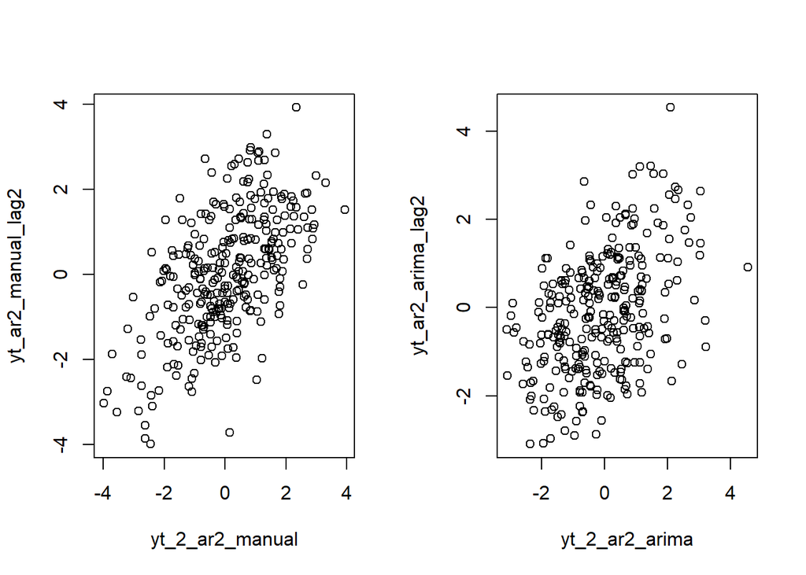

```r
plot(y=yt_ar2_arima_lag2,x=yt_2_ar2_arima)
```

#### Korelasi

```r
cor(yt_ar2_manual_lag2,yt_2_ar2_manual)
```

```
## [1] 0.5889847
```

```r
cor(yt_ar2_arima_lag2,yt_2_ar2_arima)
```

```
## [1] 0.4436581
```

Korelasi antara Yt dengan Yt−2 dari hasil simulasi mendekati perhitungan teoritis yaitu

$$\rho_2 = \phi_1 \rho_{k-1} + \phi_2
\rho_{k-2} = \frac{\phi_2(1 - \phi_2) + \phi_1^2}{1 - \phi_2} =
\frac{0.2(1 - 0.2) + 0.5^2}{1 - 0.2} = 0.5125$$

### Yt dengan Yt−3

#### Plot

```r
par(mfrow = c(1, 2))
#Yt
yt_ar2_manual_lag3 <- ar2_manual[-c(1,2,3)]
yt_ar2_manual_lag3
```

```
##   [1] -2.070930324 -0.470345231 -0.143302788 -0.740460400 -0.945522614
##   [6] -1.185305386 -1.671795045 -1.550151299 -2.107821103 -2.140194706
##  [11] -1.427202757 -0.182146261 -0.486799176 -0.790838346 -1.403974425
##  [16] -1.697326562  1.286377013  0.437811414 -0.014504787 -0.360237983
##  [21]  0.276569492 -0.627483098 -1.706632561 -0.404057179 -1.567010825
##  [26] -0.879455148 -1.689078340  0.081867346 -0.772475074 -1.079304105
##  [31] -1.195405128 -2.442656854 -2.628028715 -3.982585377 -3.857891624
##  [36] -3.019756746 -2.747354238 -0.528132203 -1.882179673 -1.902080911
##  [41] -1.608099392 -2.178805954 -2.379537173 -2.732847970 -3.094317305
##  [46] -2.617556366 -2.424491601 -3.541788331 -2.837868410 -3.236181496
##  [51] -3.200626439 -2.409859042 -1.281998990  0.524846169 -0.767330137
##  [56]  1.327213794 -0.647667678  0.598197384  2.718556227  1.444157201
##  [61]  0.596156266  0.579304817  2.185968110  0.070237282  1.840139442
##  [66]  2.263681968  1.836341670  1.377800067  0.600699629  0.209385895
##  [71]  0.873119441  2.548707761  1.295579356 -0.233169716 -0.581050764
```

[output cut: 45 more lines]

```r
# Yt-3
yt_3_ar2_manual <- ar2_manual[-c(298,299, 300)]
yt_3_ar2_manual
```

```
##   [1] -1.207065749 -0.326103633  0.679976211 -2.070930324 -0.470345231
##   [6] -0.143302788 -0.740460400 -0.945522614 -1.185305386 -1.671795045
##  [11] -1.550151299 -2.107821103 -2.140194706 -1.427202757 -0.182146261
##  [16] -0.486799176 -0.790838346 -1.403974425 -1.697326562  1.286377013
##  [21]  0.437811414 -0.014504787 -0.360237983  0.276569492 -0.627483098
##  [26] -1.706632561 -0.404057179 -1.567010825 -0.879455148 -1.689078340
##  [31]  0.081867346 -0.772475074 -1.079304105 -1.195405128 -2.442656854
##  [36] -2.628028715 -3.982585377 -3.857891624 -3.019756746 -2.747354238
##  [41] -0.528132203 -1.882179673 -1.902080911 -1.608099392 -2.178805954
##  [46] -2.379537173 -2.732847970 -3.094317305 -2.617556366 -2.424491601
##  [51] -3.541788331 -2.837868410 -3.236181496 -3.200626439 -2.409859042
##  [56] -1.281998990  0.524846169 -0.767330137  1.327213794 -0.647667678
##  [61]  0.598197384  2.718556227  1.444157201  0.596156266  0.579304817
##  [66]  2.185968110  0.070237282  1.840139442  2.263681968  1.836341670
##  [71]  1.377800067  0.600699629  0.209385895  0.873119441  2.548707761
```

[output cut: 45 more lines]

```r
plot(y=yt_ar2_manual_lag3,x=yt_3_ar2_manual)

#Yt
yt_ar2_arima_lag3 <- ar2_arima[-c(1,2,3)]
yt_ar2_arima_lag3
```

```
##   [1] -1.784562216 -2.074856748 -0.603346856  0.115336517  1.979928265
##   [6]  0.519205299 -0.696176184 -1.468891852 -1.927645533 -0.617721121
##  [11] -3.073969845 -1.105255535 -1.544078453 -0.780667738 -1.441119681
##  [16] -2.237546251 -1.120567457 -2.338668243 -1.598298743 -1.702689791
##  [21] -2.250655081 -2.969989827 -1.661653202 -0.190403943  0.288746608
##  [26]  0.192231777 -0.568477298 -2.040429169 -1.485135159 -0.811636997
##  [31] -0.443239566  0.675068462  1.054017939  2.125241038 -0.883076182
##  [36] -1.671984404 -2.580559885 -2.313009738 -1.734646274 -2.008357108
##  [41] -0.008284272 -1.275232709 -1.213701396 -0.652328651 -0.555429203
##  [46]  0.665476831  0.487308486 -1.231349306 -1.620098695 -1.397786958
##  [51] -0.680197409 -0.629349571 -1.020774866 -0.975089143 -1.448311341
##  [56] -0.144248036 -0.782066972 -1.452734085 -1.920048812  0.106817503
##  [61]  0.488751193 -0.405237469  0.730079241 -0.674487846 -1.261319914
##  [66] -2.357243530 -2.798441847 -3.095940472 -0.462035605 -0.500110261
##  [71] -1.767886587  0.460671138  0.318425904  1.353262104  0.216943712
```

[output cut: 45 more lines]

```r
# Yt-3
yt_3_ar2_arima <- ar2_arima[-c(298,299, 300)]
yt_3_ar2_arima
```

```
##   [1]  1.172148447 -0.437733455 -1.926194858 -1.784562216 -2.074856748
##   [6] -0.603346856  0.115336517  1.979928265  0.519205299 -0.696176184
##  [11] -1.468891852 -1.927645533 -0.617721121 -3.073969845 -1.105255535
##  [16] -1.544078453 -0.780667738 -1.441119681 -2.237546251 -1.120567457
##  [21] -2.338668243 -1.598298743 -1.702689791 -2.250655081 -2.969989827
##  [26] -1.661653202 -0.190403943  0.288746608  0.192231777 -0.568477298
##  [31] -2.040429169 -1.485135159 -0.811636997 -0.443239566  0.675068462
##  [36]  1.054017939  2.125241038 -0.883076182 -1.671984404 -2.580559885
##  [41] -2.313009738 -1.734646274 -2.008357108 -0.008284272 -1.275232709
##  [46] -1.213701396 -0.652328651 -0.555429203  0.665476831  0.487308486
##  [51] -1.231349306 -1.620098695 -1.397786958 -0.680197409 -0.629349571
##  [56] -1.020774866 -0.975089143 -1.448311341 -0.144248036 -0.782066972
##  [61] -1.452734085 -1.920048812  0.106817503  0.488751193 -0.405237469
##  [66]  0.730079241 -0.674487846 -1.261319914 -2.357243530 -2.798441847
##  [71] -3.095940472 -0.462035605 -0.500110261 -1.767886587  0.460671138
```

[output cut: 45 more lines]

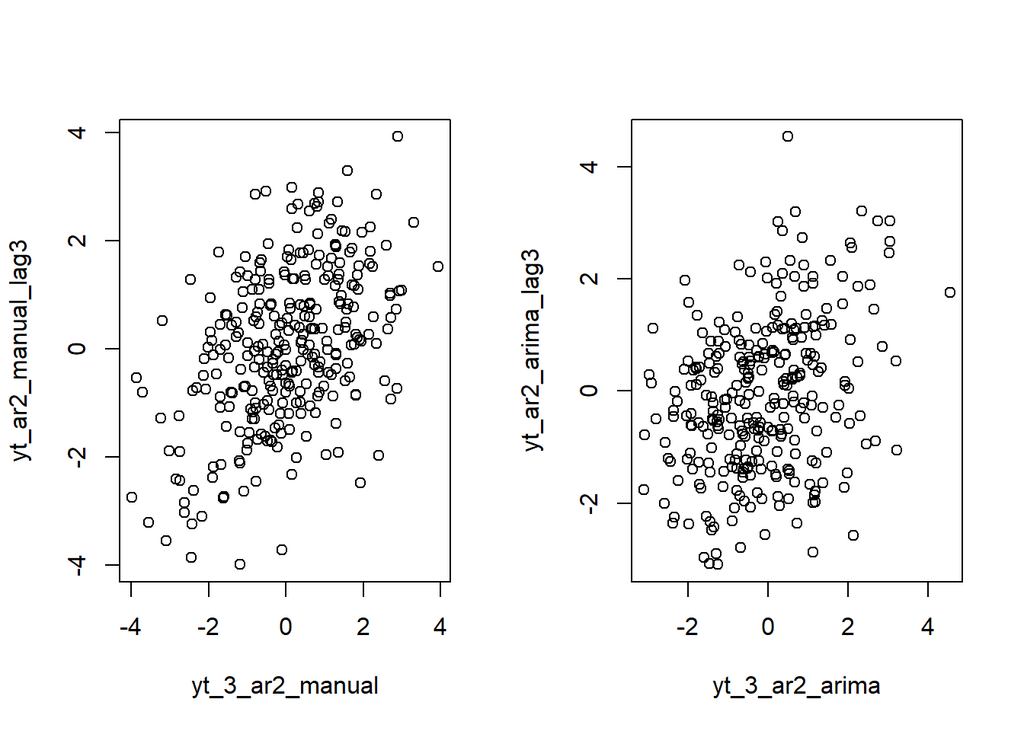

```r
plot(y=yt_ar2_arima_lag3,x=yt_3_ar2_arima)
```

Berdasarkan scatterplot tersebut, terlihat bahwa terdapat hubungan positif antara Yt dengan Yt−3. Hal ini sesuai dengan teori yang ada

#### Korelasi

```r
cor(yt_ar2_manual_lag3,yt_3_ar2_manual)
```

```
## [1] 0.4630342
```

```r
cor(yt_ar2_arima_lag3,yt_3_ar2_arima)
```

```
## [1] 0.3238443
```

Korelasi antara Yt dengan Yt−3 dari hasil simulasi mendekati perhitungan teoritis yaitu

$$\rho_3 = \phi_1 \rho_2 + \phi_2 \rho_1
= (0.5 \times 0.5125) + (0.2 \times 0.625) = 0.25625 + 0.125 = 0.38125$$

# Proses ARMA(2,2)

## Membangkitkan model ARMA(2,2)

### Manual

```r
phi1 = 0.5
phi2 = 0.2
theta1 = 0.4
theta2 = 0.6

y.arma=c(1:n)
for (i in 3:n){
  y.arma[i] = phi1*y.arma[i-1] + phi2*y.arma[i-2] +
    theta1*wn[i-1] + theta2*wn[i-2] + wn[i]
}
y.arma
```

```
##   [1]  1.00000000  2.00000000  1.67117342 -0.50987697  0.22080651 -0.72128499
##   [7] -0.43132398 -0.83281330 -1.63062016 -2.42567048 -2.71083830 -3.56383947
##  [13] -3.78601149 -3.45084825 -1.96310117 -1.35953282 -1.05181391 -1.97958403
##  [19] -2.70841035 -0.21587273 -0.05149915  0.94352638 -0.09490594  0.13021106
##  [25] -0.72808885 -1.78794156 -1.46034694 -2.75043816 -1.74703563 -2.97980280
##  [31] -1.12047340 -1.75244048 -1.33861366 -2.09018485 -3.56807587 -4.32208639
##  [37] -6.49920181 -7.02759879 -6.95235468 -6.26990810 -3.43886405 -3.74179639
##  [43] -2.97179497 -3.49821125 -3.96327268 -4.21590274 -4.99193387 -5.61516924
##  [49] -5.49498478 -5.32809897 -6.08211455 -5.70927547 -6.49639940 -6.19781821
##  [55] -5.63181708 -4.16631738 -1.43386802 -1.32659043  1.33518992 -0.57717987
##  [61]  1.13545887  2.56923479  2.89049829  2.80495301  1.68426174  2.77538387
##  [67]  1.29220747  3.17981526  3.04188015  3.84589815  3.47054593  2.25362467
##  [73]  1.27634580  1.31729358  3.02358708  2.83893413  1.81428669  0.10302897
##  [79] -0.45121970 -0.85290753 -0.66635425 -0.93510416 -2.14779642 -2.08562341
##  [85] -1.51503473 -0.24121274  0.91556687  0.64537308  0.48311177 -1.14217407
```

[output cut: 35 more lines]

### arima.sim

```r
arma22 <- arima.sim(list(order=c(2,0,2), ar = c(0.5,0.2), ma = c(0.4,0.6)), n=300)
arma22
```

```
## Time Series:
## Start = 1
## End = 300
## Frequency = 1
##   [1]  1.99672450  0.50022694 -1.36027652 -3.08346416 -2.73757924 -3.40811247
##   [7] -2.96022156 -1.28575528  1.93343236  2.45248957  4.13284826  2.64419753
##  [13]  3.99266224  2.02264256  1.67674152 -0.15597163  0.59311857 -1.07092032
##  [19]  0.53947108 -0.34927011 -0.14923335  0.81983669  1.43188003  0.70916026
##  [25]  0.02253246  0.28484319  0.35336987  1.43244964  0.94333883 -0.06337770
##  [31] -0.04371294 -1.65435134 -0.18245926 -0.45203704 -0.31947470 -2.22618972
##  [37] -0.83678946 -2.35386843 -0.51198413  0.11383002  0.13620004  1.02031966
##  [43]  0.06170341  0.83237124 -0.65575308  0.31579383 -0.44621130 -0.08262191
##  [49] -0.60090009 -0.66610380 -1.14519462 -0.27722557 -0.94386653 -1.78365745
##  [55] -0.20609521  1.10663125  1.67103111  1.14867008  0.80597227 -0.78263044
##  [61]  0.41509877 -0.54452787 -0.50314966 -0.74623057 -0.55115213 -0.34038902
```

[output cut: 39 more lines]

## Karakteristik ARMA (2,2)

### Plot Time Series

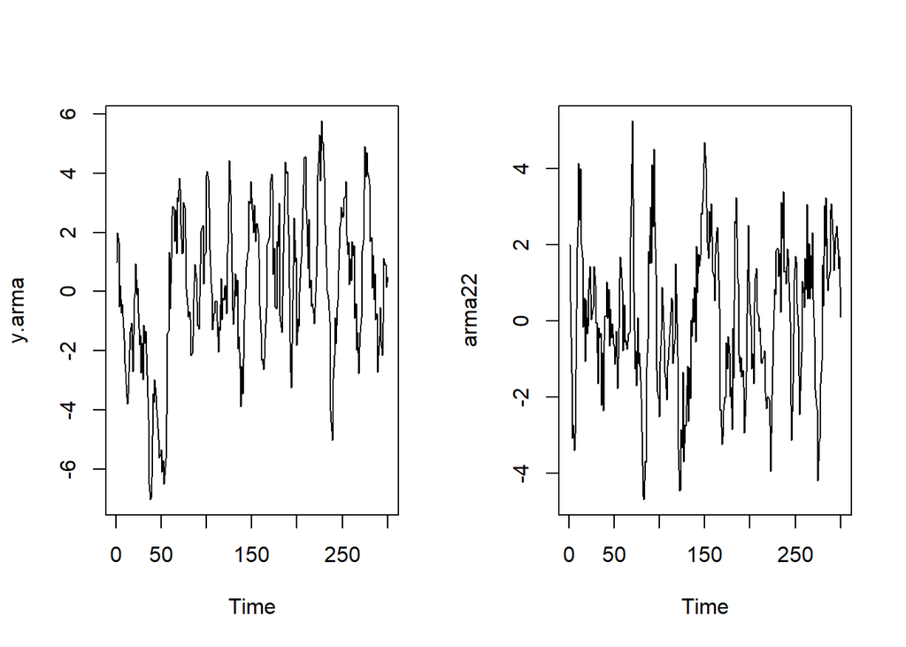

```r
par(mfrow = c(1, 2))
ts.plot(y.arma)
ts.plot(arma22)
```

Berdasarkan plot time series tersebut, terlihat bahwa model ARMA(2,2) stasioner dalam rataan.